# Measurement Error in Australian GDP Growth: A State-space Model with Serially Correlated Errors and Stochastic Volatility

Working paper draft

Author

David Stephan

Published

October 19, 2026

# Abstract

We treat true Australian GDP growth as a latent state observed with error through the expenditure, income and production measures, estimate thirteen Bayesian state-space specifications on the 2026 Q2 vintage, and compare them by one-step-ahead predictive density, with latent states integrated out, over 1990 Q1 to 2026 Q2. The most robust finding is that measurement errors are negatively serially correlated: on average an expenditure-side error is followed the next quarter by an error of opposite sign about 0.43 times its size. Allowing for this improves prediction on both estimation samples, with and without stochastic volatility. The gain from time-varying measurement-error variance roughly halves when estimation starts in 1980 rather than 1959. The production model adds stochastic volatility to latent growth. It ranks first, but its margin is thin (Newey-West z of 2.06 from 1959, 1.57 from 1980) and the specification was chosen after seeing related results on the same window. On 1980 Q1 to 2026 Q2 the variance of a posterior draw of latent growth is 87% of the variance of headline growth (90% interval 81% to 94%). On RDP 2014-12’s sample (1980–2013) our closest model reproduces their baseline estimates. The evaluation is pseudo-real-time on one vintage and does not test the variance split.

# 1 Introduction

The Australian Bureau of Statistics (ABS) publishes three quarterly estimates of real GDP: GDP(E) from expenditure, GDP(I) from income and GDP(P) from production. In concept they measure the same thing. In practice they are built from different source data and differ every quarter. The headline figure, GDP(A), is their simple average. A user who wants to know how fast the economy grew last quarter has to decide how much of each measure’s movement is signal.

This paper treats true quarterly growth as a latent state and the three published measures as noisy readings of it. The question is how much of the quarter-to-quarter movement in measured growth is measurement error, and what the error looks like: how large it is, whether it persists or reverses, whether it is correlated across the three measures, and whether its size has changed over six decades of national accounting. The answer matters for anyone who reads a single quarter’s GDP print. It affects how much weight a quarterly surprise should carry in a policy assessment, how persistent true growth is, and how much the published series overstates the volatility of activity.

The work began as a replication and extension of Rees et al. (2014) (hereafter RDP 2014-12). They applied the state-space approach that Aruoba et al. set out in a 2013 working paper (journal version: Aruoba et al. (2016)) to Australian data from 1980 Q1 to 2013 Q2 and found that the latent series was considerably smoother than GDP(A). We revisit that question with thirteen years more data, a sample that includes the COVID-19 collapse of 2020 Q2, and a different set of extensions. The paper makes four contributions.

1. **A model family.** We estimate thirteen specifications. They add, one or two at a time, an AR(1) latent state, correlated measurement errors, serially correlated (AR(1)) measurement errors, stochastic volatility (SV) in the measurement errors, SV in latent growth, a COVID-specific variance scale, and labour-market signals.
2. **A valid comparison.** Every specification has a latent state per quarter, and some have one log-variance per quarter and measure. Pointwise leave-one-out cross-validation on such models is not informative, and an earlier version of this project relied on it. We replace it with Pareto-smoothed importance-sampling leave-future-out cross-validation (PSIS-LFO-CV; Bürkner et al. (2020)) of the one-step-ahead predictive density, with the latent states integrated out by exact Kalman filters or Rao-Blackwellised particle filters. We report Monte Carlo error, particle-filter bias checks, autocorrelation-robust standard errors and the effect of refit retries.
3. **Findings on the error process.** Measurement errors are negatively autocorrelated; their variance has fallen over time; and on the post-1980 sample the expenditure and income errors are only weakly correlated with each other.
4. **A documented production model.** The preferred specification is published as a weekly-refreshed estimate. Each change of model was made under a switch rule fixed before the candidate’s results were known, and the paper reports the observed values against those rules. The later move of the estimation sample to 1980 Q1 was not made under such a rule (Section 12).

The main results are as follows. All numbers are in annualised percentage points (400 times the quarterly log change) unless stated otherwise.

- Serially correlated measurement errors improve the predictive density by +20.4 nats over 146 quarters when estimation starts in 1980 (Newey-West z 9.4), and by +27.4 from 1959. The AR(1) coefficient of the expenditure error in the production model is −0.43 [−0.54, −0.31] (posterior median and 90% interval).
- Stochastic volatility in the measurement errors improves prediction by +72.5 nats from 1959 (z 3.8) but only +33.4 from 1980 (z 2.1). About half of the full-sample gain comes from the noisy pre-1980 data used to train the constant-variance models.
- Stochastic volatility in latent growth gives the best model on every target. The margin over the same model without it is +59.6 nats from 1959 (z 2.06) and +57.4 from 1980 (z 1.57). One quarter, 2020 Q2, dominates the standard error.
- In the production model (1980 Q1 to 2026 Q2), latent volatility falls from 3.1 in the 1980s to 1.3 in the 2010s (decade averages of the innovation standard deviation) and is 13.7 in 2020 Q2. Latent growth in 2020 Q2 is −27.9 against a headline of −28.1.
- Re-estimated on RDP 2014-12’s sample period (1980 Q1 to 2013 Q2), our m2, which has the structure of their Model 1, reproduces its estimates closely: latent persistence 0.43 against 0.40, and a posterior-median path whose standard deviation is 73% of the headline’s against their 75%. Fitted to 2026, the same model is much less smooth, and fits ending in 2019 show that the COVID quarters cause the difference.

The evidence has clear limits, which we state up front and return to in Section 10. The comparison is pseudo-real-time: every forecast uses the current data vintage, so we do not reproduce RDP 2014-12’s real-time revision analysis. The production model was proposed after a related model’s results had been seen on the same evaluation window, so its z-statistics overstate the evidence; even a two-try Bonferroni bar, itself a lower bound on the correction, would not be met. The evaluation window is the same for every model and every round of the project. Predictive scores test the model’s forecasts of the observed measures, not its split of measured growth into signal and noise; models that cannot be told apart by score can imply quite different splits. And the labour-market signal we use is hours worked, not the unemployment rate used by RDP 2014-12. Our re-estimation on RDP 2014-12’s sample period covers only the models in our family; their correlated-error model and their unemployment model have no counterpart here (Section 9).

The rest of the paper is organised as follows. Section 2 reviews related work. Section 3 describes the data. Section 4 sets out the model family and Section 5 the estimation method. Section 6 describes the evaluation, Section 7 the results and Section 8 the robustness checks. Section 9 relates the results to RDP 2014-12. Section 10 discusses limitations and Section 11 concludes. The appendices record the history of the production model, full diagnostics, filter tests, results that were withdrawn, and how to reproduce every number.

# 2 Related literature

**GDP measurement error.** Aruoba et al. (2016) combine US expenditure- and income-side GDP in a state-space model in which true growth is latent and the errors may be correlated with each other and with true growth, which raises an identification problem. Nalewaik (2010) compares the two US measures and argues that the income side tracks the business cycle better. RDP 2014-12 (Rees et al. 2014) apply that approach to the three Australian measures. They estimate three models: independent errors (their Model 1); errors correlated with each other and with the latent innovation (Model 2), identified, following the working-paper version of Aruoba et al., by fixing the ratio of latent to GDP(E) variance at 0.5; and a fourth signal, the change in the unemployment rate (Model 3). The standard deviation of their posterior-median latent path is 25% (Model 1), 26% (Model 2) and 36% (Model 3) lower than that of GDP(A), and their estimates are revised less in real time. Bishop et al. (2013) document revisions to Australian GDP and find that GDP(P) is revised least. A separate literature models data revisions directly, with “true” values as a latent state and each vintage as a noisy or news-driven measurement (Jacobs and van Norden 2011; Kishor and Koenig 2012). Croushore (2011) surveys real-time analysis. We work with a single vintage and do not model revisions.

**Stochastic volatility in macroeconomic models.** Stationary AR(1) log-variance processes, estimated by MCMC, go back to Jacquier et al. (1994) and Kim et al. (1998). Time-varying volatility became standard in macroeconomic time series after the evidence of a decline in output volatility from the mid-1980s (McConnell and Perez-Quiros 2000; Stock and Watson 2002). Cogley and Sargent (2005) and Primiceri (2005) put SV into vector autoregressions. Stock and Watson (2007) model US inflation as an unobserved-components model with SV in both the permanent and transitory components; our latent-plus-measurement-error SV structure is close in spirit. Clark (2011) shows that SV improves real-time density forecasts.

**COVID-19.** The pandemic quarters are extreme observations for any linear Gaussian time-series model. Lenza and Primiceri (2022) propose scaling the innovation variance of a vector autoregression by estimated factors for March, April and May 2020, which then decay at an estimated rate. Carriero et al. (2024) compare that approach with SV and outlier-adjusted SV. Our specification m7 applies a related idea, a free scale for each of four COVID quarters, to the measurement errors; m10 and m13 instead let SV in latent growth absorb the shock.

**State-space methods.** Durbin and Koopman (2012) is the standard reference for the Kalman filter and smoother. We draw latent paths by forward-filtering backward-sampling (Carter and Kohn 1994; Frühwirth-Schnatter 1994). For the SV models we integrate the latent growth state out analytically, conditional on the log-variance paths, and use particles only for the log-variances. This is Rao-Blackwellisation (Doucet et al. 2000) or, in the form we use, a mixture Kalman filter (Chen and Liu 2000). The particle filter’s likelihood estimate is unbiased, but its logarithm is biased downwards at finite particle counts (Pitt et al. 2012); Gordon et al. (1993) and Chopin and Papaspiliopoulos (2020) give general background.

**Model evaluation.** PSIS-LOO (Vehtari et al. 2017) with Pareto smoothing (Vehtari et al. 2024) approximates leave-one-out cross-validation from a single fit. Bürkner et al. (2020) adapt it to time series: PSIS-LFO-CV approximates the sequence of one-step-ahead predictive densities from a few refits. The log predictive density is a strictly proper scoring rule (Gneiting and Raftery 2007) and is the natural score for comparing Bayesian predictive distributions (Geweke and Amisano 2010). Score differences between models are averages of autocorrelated terms, so we use Newey-West standard errors (Newey and West 1987; Andrews 1991), in the spirit of Diebold and Mariano (1995).

**Computation.** All models are written in Stan (Carpenter et al. 2017) and sampled with the No-U-Turn sampler (Hoffman and Gelman 2014). Non-centred parameterisations of hierarchical states follow Papaspiliopoulos et al. (2007). We assess convergence with rank-normalised R-hat and bulk and tail effective sample sizes (Vehtari et al. 2021), and use the energy Bayesian fraction of missing information (E-BFMI) to detect poor exploration of heavy-tailed posteriors (Betancourt 2016, 2017). The LKJ prior on correlation matrices is from Lewandowski et al. (2009).

# 3 Data

**Source and vintage.** The data are ABS 5206.0, Table 24 (Selected Analytical Series): GDP(E), GDP(I) and GDP(P), chain volume measures, seasonally adjusted (Australian Bureau of Statistics, n.d.). We use the release for the June quarter of 2026, the latest at the time of writing. The levels run from 1959 Q3 to 2026 Q2. We take $y^k_t = 400\,\Delta\log Y^k_t$ for $k \in \{E, I, P\}$, giving 267 quarterly growth rates from 1959 Q4 to 2026 Q2. The headline series is the mean of the three, $\bar y_t = (y^E_t + y^I_t + y^P_t)/3$.

**Units.** Every model is estimated in annualised percentage points, and this paper reports in that unit throughout. To convert to the quarter-on-quarter percentages the ABS and the published site use, divide by four (standard deviations) or sixteen (variances). Log predictive densities are reported in the annualised unit as well. Changing to quarterly units adds the same constant, $3\log 4 \approx$ 4.16 nats per quarter, to every model’s score, so score differences are unaffected.

**Two samples.** RDP 2014-12 start their data in 1980 Q1. Their reason is that the quality of the underlying source data has changed over time, “so that the pattern of measurement errors in the early years of each GDP series may be unrepresentative of their current performance” (Rees et al. 2014, sec. 3.2). We estimate every model on two samples:

- the **full sample**, 1959 Q4 to 2026 Q2 (T = 267);
- the **1980 sample**, 1980 Q1 to 2026 Q2 (T = 186). This is the sample of the published estimate since 19 October 2026.

The labour-market models use shorter samples (Section 4). Hours worked (ABS 5206.0 Table 1) joined to GDP give 1978 Q4 to 2026 Q2 (T = 191); monthly employment (ABS 6202.0) is used by one model only.

Table 1 summarises the growth rates. On the full sample GDP(E) is the most variable measure: its variance is 1.75 times that of the headline, against 1.26 for GDP(I) and 1.09 for GDP(P). From 1980 GDP(I) is the most variable (1.44, against 1.32 for E and 1.11 for P). The pairwise correlations of the three measures are 0.58 to 0.62 on the full sample and 0.64 to 0.71 from 1980. The individual measures have negative or small first-order autocorrelation, which is the first hint that their errors partly reverse. The COVID quarters are extreme: in 2020 Q2 the three measures are −28.0, −28.4 and −27.9, so they agree to within 0.5 percentage points on a fall of about 28.

**“Excluding COVID”.** Two definitions are used, as in the project’s tables, and each is named where it is used. Variance ratios “excluding COVID” drop the five quarters 2020 Q1 to 2021 Q1. Predictive scores “excluding COVID” drop the four targets 2020 Q2 to 2021 Q1. A third variant drops all twelve quarters of 2020 to 2022.

Table 1: Summary statistics of quarterly growth, annualised per cent (400 × Δlog). $\rho_1$ is the first-order autocorrelation. Headline is the mean of the three measures. Source: ABS 5206.0 Table 24, June quarter 2026 release.

| Sample | Series | Mean | SD | $\rho_1$ | Min | Max |
| --- | --- | --- | --- | --- | --- | --- |
| 1959 Q4 – 2026 Q2 | GDP(E) | 3.25 | 6.00 | −0.30 | −28.02 | 21.95 |
| 1959 Q4 – 2026 Q2 | GDP(I) | 3.19 | 5.10 | −0.14 | −28.42 | 19.52 |
| 1959 Q4 – 2026 Q2 | GDP(P) | 3.26 | 4.74 | 0.03 | −27.93 | 17.89 |
| 1959 Q4 – 2026 Q2 | Headline | 3.23 | 4.54 | −0.06 | −28.12 | 17.40 |
| 1980 Q1 – 2026 Q2 | GDP(E) | 2.87 | 4.46 | −0.08 | −28.02 | 14.58 |
| 1980 Q1 – 2026 Q2 | GDP(I) | 2.91 | 4.66 | −0.12 | −28.42 | 15.30 |
| 1980 Q1 – 2026 Q2 | GDP(P) | 2.91 | 4.09 | 0.11 | −27.93 | 14.27 |
| 1980 Q1 – 2026 Q2 | Headline | 2.90 | 3.88 | 0.06 | −28.12 | 14.45 |

# 4 The model family

## 4.1 The production model

The production model, m13, has three layers: latent growth with time-varying volatility; serially correlated measurement errors whose innovations have time-varying volatility; and a restricted correlation structure across the three measures.

**Observation equations.** For $k \in \{E, I, P\}$,
$$y^k_t = \mu_t + \varepsilon^k_t, \qquad \varepsilon^k_t = \psi_k\,\varepsilon^k_{t-1} + u^k_t, \qquad |\psi_k| < 1.
\tag{1}$$
The innovation vector $u_t = (u^E_t, u^I_t, u^P_t)'$ is Gaussian with covariance
$$u_t \sim N(0, R_t), \qquad R_t = D_t\, C\, D_t, \qquad D_t = \operatorname{diag}\!\left(e^{h_{t,E}/2}, e^{h_{t,I}/2}, e^{h_{t,P}/2}\right), \qquad C = \begin{pmatrix} 1 & r & 0 \\ r & 1 & 0 \\ 0 & 0 & 1 \end{pmatrix},
\tag{2}$$
with $r = \rho_{EI}$. The expenditure and income errors may be correlated; the production error is independent of both. The restriction reflects how the measures are built. Real GDP(I) is obtained by deflating nominal income with the GDP(E) deflator (Rees et al. 2014, footnote 1), and the two share balancing items, while GDP(P) is built from industry value-added data.

**Measurement-error volatility.** Each innovation log-variance follows a stationary AR(1),
$$h_{t,k} = \mu_{h,k} + \phi_k\,(h_{t-1,k} - \mu_{h,k}) + \omega_k\,\xi_{t,k}, \qquad \xi_{t,k} \sim N(0,1).
\tag{3}$$
So $\sigma_{t,k} = e^{h_{t,k}/2}$ is the standard deviation of the innovation $u^k_t$, not of $\varepsilon^k_t$. At the long-run log-variance, the error itself has standard deviation $\bar\sigma^\varepsilon_k = e^{\mu_{h,k}/2}/\sqrt{1-\psi_k^2}$.

**Latent growth.** True growth follows a stationary AR(1) with its own stochastic volatility:
$$\mu_t = c + \rho\,\mu_{t-1} + e^{g_t/2}\,\eta_t, \qquad g_t = \mu_g + \phi_g\,(g_{t-1} - \mu_g) + \omega_g\,\zeta_t, \qquad \eta_t, \zeta_t \sim N(0,1).
\tag{4}$$
We write $\tau_t = e^{g_t/2}$ for the latent innovation standard deviation and $\tau = e^{\mu_g/2}$ for its value at the long-run log-variance. The long-run mean of latent growth is $\bar\mu = c/(1-\rho)$. All shocks ($\eta$, $\zeta$, $\xi$, $u$) are mutually independent.

**Initial conditions.** The log-variances start from their stationary laws, $g_1 \sim N(\mu_g, \omega_g^2/(1-\phi_g^2))$ and $h_{1,k} \sim N(\mu_{h,k}, \omega_k^2/(1-\phi_k^2))$. Latent growth starts from the stationary law it would have if its innovation variance were held at the period-1 value, $\mu_1 \sim N\!\left(c/(1-\rho),\, e^{g_1}/(1-\rho^2)\right)$. The marginal stationary law under latent SV has no closed form. The period-1 errors start from $\varepsilon_1 \sim N(0, V_1)$ with $V_{1,jk} = R_{1,jk}/(1-\psi_j\psi_k)$, the stationary covariance of the error VAR(1) at the period-1 innovation covariance. Period 1 is outside the evaluation window in every comparison.

**Nesting.** With $\omega_g = 0$ (constant $\tau_t$) the model is m12. With $\psi = 0$ as well it is m9. With $\rho_{EI}$ free in a full $3\times3$ correlation matrix and constant variances it would be m3.

## 4.2 The other specifications

Table 2 lists the thirteen specifications. They were built in rounds, and the labels m1 to m13 record the order. m1 to m5 extend the RDP 2014-12 baseline one feature at a time. m6 imposes the structural E/I-only correlation. m7 applies a COVID variance scale. m8 to m11 add labour-market data. m12 and m13 combine the features that helped.

Table 2: The thirteen specifications. ‘E–I only’ means the E and I errors have a free correlation and P is independent. SV = stochastic volatility (stationary AR(1) log-variance). T is the number of quarters on the full sample / the 1980 sample.

| Model | Latent growth | Latent variance | Error correlation | Error variance | Error dynamics | Extra signal | T |
| --- | --- | --- | --- | --- | --- | --- | --- |
| m1 | iid | constant | none | constant | white | – | 267/186 |
| m2 | AR(1) | constant | none | constant | white | – | 267/186 |
| m3 | AR(1) | constant | free (LKJ) | constant | white | – | 267/186 |
| m4 | AR(1) | constant | none | SV | white | – | 267/186 |
| m5 | AR(1) | constant | none | constant | AR(1) | – | 267/186 |
| m6 | AR(1) | constant | E–I only | constant | white | – | 267/186 |
| m7 | AR(1) | constant | none | constant × κ (COVID) | white | – | 267/186 |
| m8 | AR(1) | constant | none | constant | white | hours | 191/186 |
| m9 | AR(1) | constant | E–I only | SV | white | – | 267/186 |
| m10 | AR(1) | SV | none | SV | white | hours | 191/186 |
| m11 | AR(1), monthly | constant | none | constant | white | employment (monthly) | 193/186 |
| m12 | AR(1) | constant | E–I only | SV | AR(1) | – | 267/186 |
| m13 | AR(1) | SV | E–I only | SV | AR(1) | – | 267/186 |

Some details matter for what follows.

- **m1** has independent and identically distributed latent growth around a mean $\bar\mu$; **m2** makes it AR(1). m2 is the closest of our models to RDP 2014-12’s Model 1 (Section 9).
- **m3** has a free $3\times3$ error correlation matrix with an LKJ(4) prior. It is *not* RDP 2014-12’s Model 2, which also lets the latent innovation correlate with the measurement errors and imposes an identifying restriction on the variance ratio.
- **m4** has SV in each measurement error and constant latent variance. **m9** combines m4 with m6’s E/I-only correlation. **m12** adds m5’s AR(1) errors to m9. **m13** adds latent SV to m12.
- **m7** multiplies all three error standard deviations by a free factor $\kappa_q$, with a LogNormal(0, 1) prior, in each of 2020 Q2, Q3, Q4 and 2021 Q1. It therefore knows in advance which quarters are the COVID quarters.
- **m8** adds hours-worked growth as a fourth signal, $y^U_t = \alpha + \beta\mu_t + \varepsilon^U_t$, with constant variances. RDP 2014-12’s fourth signal is the change in the unemployment rate; we did not use it. **m10** has SV on all four errors and SV on latent growth (see below). **m11** is a mixed-frequency model with a monthly latent state, quarterly GDP measures loading on the three-month average (a simplification of Mariano and Murasawa 2003; see also Bańbura and Modugno 2014), and monthly employment as a signal. Its parameters are at monthly frequency.

## 4.3 What the failed specifications taught us

Three specifications needed diagnosis. Each episode changed the model family.

**m3: weak identification of the error correlations.** With $\rho$ near zero the latent state is close to i.i.d. Then the data identify only the cross-sectional covariance $v\mathbf{1}\mathbf{1}' + \Sigma$, where $v = \tau^2/(1-\rho^2)$, plus a weak lag-1 autocovariance $\rho v$. Adding $\delta$ to every element of $\Sigma$ and subtracting it from $v$ leaves the first unchanged. This is the identification problem that Aruoba et al. (2016) and RDP 2014-12 solve by restriction. On the full sample the posterior correlation between $\tau$ and the mean off-diagonal error correlation is −0.70. In the lowest decile of $\tau$ draws the E–I correlation averages 0.29; in the highest decile it is −0.02. The posterior standard deviations of the three correlations are 46%, 57% and 83% of their prior standard deviation. The ridge first showed up as a sampler failure. With latent growth sampled jointly, m3 had a minimum E-BFMI of 0.03 and a minimum bulk ESS of 132. After latent growth was integrated out (Section 5) it sampled cleanly (Table 18), and the weak identification remained as a property of the model. m6’s E/I-only restriction is the structural alternative.

**m10: two modes, and a re-specification.** The first version of m10 had constant latent variance and SV on four measurement errors, estimated from 1978 Q4. It had two posterior modes. Of 16 chains started from dispersed values, 9 found mode A ($\rho \approx$ 0.39, $\tau \approx$ 2.1). In mode A latent growth in 2020 Q2 was −1.3, so the model read COVID as four coincident errors of about −27 in four separately compiled series, and the latent variance ratio was 0.36. Another 3 chains found mode B ($\tau \approx$ 3.6, latent 2020 Q2 −26.9), which inflated $\tau$ for every quarter. The remaining 4 were stranded between the two. Both modes are responses to one misspecification. With a constant latent standard deviation calibrated to the post-1978 sample, the 2020 Q2 fall is a latent shock of roughly 13 standard deviations. The model must either inflate the latent variance everywhere or call a common shock measurement error. A reparameterisation cannot fix that. We re-specified m10 with SV on latent growth (Equation 4), using the same priors as each measurement SV block. The economic justification does not depend on the fit: output volatility fell after the mid-1980s, and COVID was a real shock on which the measures agree. After re-specification, 16 chains from dispersed starting values all reached one mode (log posterior −2,338 to −2,334, latent 2020 Q2 −28.2 to −28.1). 4 further chains started at an old mode-A configuration all left it for the same mode. This re-specification was chosen after the old model’s fit and LFO score had been seen, so the new m10’s predictive gains are post hoc. m13 is m12 with the same latent SV block; Section 7 and Section 10 discuss what that implies.

**m4: an artefact of the sampling coordinates.** The first SV specification used a random-walk log-variance anchored at the start. It was unidentified (R-hat about 1.6). A stationary AR(1) log-variance replaced it. With latent growth sampled jointly, one persistence parameter then looked bimodal (R-hat 1.30). With latent growth integrated out the bimodality disappeared (Table 18). It was a sampler artefact of the coupling between latent growth and the log-variances, not a feature of the posterior.

# 5 Estimation

## 5.1 Priors

Table 3: Priors of the production model m13 (annualised units), and of the research variant with tighter priors (Section 7.6, Section 8.2.1; not used in production). N(m, s) has standard deviation s; half-N is a normal on a positive parameter; normals on (−1, 1) parameters are truncated. In the variant $s_g$ and $s_k$ are the stationary standard deviations of the log-variances. Source: stan/m13_serial_latent_sv.stan, stan/m13_tight_priors.stan and priors.md.

| Parameter | Role | Prior | Tighter-prior variant |
| --- | --- | --- | --- |
| $c$ | latent intercept; $\bar\mu = c/(1-\rho)$ | N(1.5, 1) | $c = \bar\mu(1-\rho)$, $\bar\mu \sim$ N(3, 2) |
| $\rho$ | latent persistence | N(0.5, 0.3) on (−1, 1) | Beta(2.625, 2.625) on (0, 1) |
| $\mu_g$ | latent log-variance, long-run mean | N(2, 1) | as m13 |
| $\phi_g$ | latent log-variance persistence | Uniform(−1, 1) | as m13 |
| $\omega_g$ | latent log-variance innovation sd | half-N(0, 0.5) | $\omega_g = s_g\sqrt{1-\phi_g^2}$, $s_g \sim$ half-N(0, 1) |
| $\mu_{h,k}$ | error log-variance, long-run mean | N(2, 1) | as m13 |
| $\phi_k$ | error log-variance persistence | Uniform(−1, 1) | as m13 |
| $\omega_k$ | error log-variance innovation sd | half-N(0, 0.5) | $\omega_k = s_k\sqrt{1-\phi_k^2}$, $s_k \sim$ half-N(0, 1) |
| $\rho_{EI}$ | E–I innovation correlation | N(0, 0.5) on (−1, 1) | as m13 |
| $\psi_k$ | error AR(1) coefficient | N(0, 0.5) on (−1, 1) | as m13 |

Table 3 lists m13’s priors. The other three-measure models use the same priors for the parameters they share with m13, with three exceptions. Models with a constant latent standard deviation (all except m10 and m13) put a half-N(0, 2) prior on $\tau$, and the constant-variance models put half-N(0, 2) priors on the error standard deviations. m1 has a N(3, 2) prior on its mean $\bar\mu$. m11 works at monthly frequency and has its own priors (for example $\rho \sim N(0.9, 0.1)$ and half-N(0, 5) on its monthly latent and employment standard deviations; see priors.md). The scales are weakly informative for growth of about 3% a year with swings of a few percentage points. At $\mu_g \sim N(2,1)$ the prior median of $\tau$ is $e \approx 2.7$. The scales were set by hand from sample moments. A prior predictive simulation, run for this paper after the comparison, is reported in Section 7.6. It shows that these priors put noticeable mass on implausibly volatile economies, so we also fitted a research variant with tighter priors chosen from the prior predictive alone (last column of Table 3). Its results are in Section 8.2.1; production uses m13’s priors.

## 5.2 Integrating out latent growth

Conditional on the log-variance paths $g$ and $h$ and the hyperparameters, m13 is linear and Gaussian in $\mu$. Quasi-differencing removes the AR(1) errors exactly:
$$y_t - \psi \circ y_{t-1} = \mathbf{1}\mu_t - \psi\,\mu_{t-1} + u_t, \qquad t \ge 2,
\tag{5}$$
where $\circ$ is the element-wise product. The quasi-differenced data load on the two-dimensional state $(\mu_t, \mu_{t-1})$. A Kalman filter on that state gives $\log p(y \mid g, h, \theta)$ exactly, and the model block adds it to the target. Hamiltonian Monte Carlo then explores only the hyperparameters and the log-variances. In generated quantities, latent growth is drawn exactly from $p(\mu \mid y, g, h, \theta)$ by forward-filtering backward-sampling (Carter and Kohn 1994; Frühwirth-Schnatter 1994). The backward step uses the joint filtered law of $(\mu_{t+1}, \mu_t)$, because $y_{t+1}$ also depends on $\mu_t$. When this step was developed for m12, the tests showed that reusing m9’s scalar-state backward step would give a worst error of 51.6 Monte Carlo standard errors against the dense smoother. The log-determinant and quadratic form of the innovation covariance are written as sums of squares (via the Cauchy–Binet and Lagrange identities), so no term can cancel numerically.

The same Rao-Blackwellisation is used in every SV model. It was the most important computational change in the project. Before it, the production model of the time (m9) sampled latent growth jointly with the log-variances. That produced a funnel whose pathologies grew with the sample: on the 2026 Q2 vintage the last continuous-integration fit with joint sampling had 44 divergences in 8,000 draws and a minimum E-BFMI of 0.087.

## 5.3 Parameterisation and the stall diagnosis

The log-variances are non-centred (Papaspiliopoulos et al. 2007): the sampler works with the standardised innovations $\xi_{t,k}$ and $\zeta_t$, and $h$ and $g$ are built from them.

The E–I correlation is sampled as $z_{EI} = \operatorname{atanh}(\rho_{EI})$, with the Jacobian added explicitly. The prior on $\rho_{EI}$ is unchanged. The reason is numerical. With Stan’s built-in $(-1, 1)$ transform, a warmup-stall harness found that 3 of 100 chains from Stan’s default random initial values (and 2 of 100 with narrower initial values) stalled in early warmup. Their step size collapsed and they ran at maximum tree depth without moving. Most sat at $\rho_{EI} = -1$, where $1-\rho_{EI}^2$ rounds to zero. Writing $1 \pm \rho_{EI} = 2\,\mathrm{logit}^{-1}(\pm 2 z_{EI})$ avoids the cancellation. With this form 0 of 200 chains stalled. The same harness on m13 found 0 stalls in 100 chains with default initial values and 0 in 40 with narrower ones.

## 5.4 Sampler settings, the publication gate and computing time

Every full fit uses 4 chains of 2,000 warmup and 2,000 sampling iterations (8,000 draws), seed 1. The SV models use a target acceptance rate (adapt_delta) of 0.99 and a maximum tree depth of 12. Models are fitted through cmdstanr; the continuous-integration production run uses CmdStan 2.39.0.

The published estimate is produced only if the fit passes a gate fixed in advance: divergent transitions below 0.1% of draws; minimum E-BFMI over chains at least 0.3; R-hat at most 1.01 on every hyperparameter and at most 1.05 on every $\mu_t$, $h_{t,k}$ and $g_t$; bulk and tail ESS at least 400 on every hyperparameter and every $\mu_t$. Any missing diagnostic counts as a failure.

The production fit on the 1980 sample (seed 1) had 0 divergences, a minimum E-BFMI of 0.882, a maximum hyperparameter R-hat of 1.0013 and a minimum hyperparameter bulk ESS of 1,315 (on phi[1]). Sampling took 1,042 seconds with four parallel chains on a six-core machine. A seed-2 fit also passed (Table 19). The full-sample fit of m13 took 1,384 seconds of wall time. m4, m9 and m10 took between 404 and 564 seconds on the full sample. m12’s research fit took 2,396 seconds with only 2 parallel chains; its production run with four took 1,260 seconds. Constant-variance models take under two minutes (Table 18). According to the repository README, the whole continuous-integration job for the 1980-sample production fit takes about 27 minutes on GitHub’s runners.

The estimate on the public site is refitted weekly by a continuous-integration job on GitHub’s runners. That run gave different draws from the local fit with the same seed. The repository does not document why; CmdStan does not guarantee identical draws across machines. Its diagnostics (`docs/diagnostics.json`) are 2 divergences, minimum E-BFMI 0.846, maximum hyperparameter R-hat 1.0031 and minimum hyperparameter bulk ESS 1,285. The published median path differs from the local one by at most 0.017 quarter-on-quarter percentage points. All estimates in this paper come from the local fit.

# 6 Evaluation method

## 6.1 Why pointwise leave-one-out was invalid

An earlier version of this project ranked models by PSIS-LOO on the saved pointwise log-likelihood $\log p(y_t \mid \mu_t, h_t, \theta)$. That comparison was not evidence, for three reasons.

1. **The latent states were not integrated out.** Every specification has a latent $\mu_t$ per quarter, and the SV models have $h_{t,k}$ as well. The pointwise term conditions on states that were fitted to the left-out observation. Leaving $y_t$ out requires a large change in the posterior of $\mu_t$, which importance sampling from the full posterior cannot capture.
2. **The effective number of parameters was close to T.** On the full sample, $p_{\text{loo}}$ was 205 to 390 for T = 267.
3. **Most Pareto $\hat k$ values exceeded 0.7:** 187 to 242 of 267 for the three-measure models. The PSIS estimates were unreliable for most observations.

The withdrawn claims, which included a gain of about 240 nats for SV, are listed in Section 15.

## 6.2 PSIS-LFO-CV with latent states integrated out

The score is the sum of one-step-ahead log predictive densities over an evaluation window $W$:
$$\mathrm{elpd}_{\mathrm{LFO}} = \sum_{t \in W} \log p(y_t \mid y_{1:t-1}), \qquad p(y_t \mid y_{1:t-1}) = \int p(y_t \mid y_{1:t-1}, \theta)\, p(\theta \mid y_{1:t-1})\, d\theta.
\tag{6}$$
Here $\theta$ collects only the hyperparameters. The latent states, including the log-variance paths, are integrated out by a filter, so each term conditions only on the past. The target is the vector of three measures, so the score rewards a model for predicting each measure, not only the headline.

**Approximation.** Following Bürkner et al. (2020), we fit the model to $y_{1:i^*}$ and reuse its draws $\theta_s$ for later targets. Importance ratios $r_s = \prod_{j=i^*+1}^{i} p(y_j \mid y_{1:j-1}, \theta_s)$ turn them into draws from $p(\theta \mid y_{1:i})$. The ratios are Pareto-smoothed (Vehtari et al. 2024), and the target density is $\sum_s w_s\, p(y_{i+1} \mid y_{1:i}, \theta_s)$. When the Pareto $\hat k$ of the ratios exceeds 0.7, the model is refitted on $y_{1:i}$. Refits use 4 chains of 1,000 warmup and 1,000 sampling iterations with each model’s own sampler settings, and at most 12 refits are allowed per model.

**Window.** The window is 1990 Q1 to 2026 Q2, 146 targets, the same calendar quarters for every model. The initial training sample is 1959 Q4 to 1989 Q4 (121 quarters) for the full-sample run and 1980 Q1 to 1989 Q4 (40 quarters) for the 1980 run. The labour models start later (Table 2).

**Filters.** The linear-Gaussian specifications use an exact Kalman filter on every posterior draw. The SV specifications (m4, m9, m10, m12, m13) use a Rao-Blackwellised particle filter: particles over the log-variances $(g, h)$, and an exact Kalman filter over latent growth for each particle (Doucet et al. 2000; Chen and Liu 2000). The m10 and m13 filters use a locally adapted proposal for $g$ with an exact weight correction. At a fixed 2,000 particles, the adapted proposal halved the run-to-run standard deviation of the COVID-quarter scores (0.65 against 1.38 nats on 12 test draws) relative to the bootstrap proposal (Gordon et al. 1993).

**Particle schedule.** A pilot pass on 200 draws measures the particle effective sample size in each quarter. The particle count is 2,000 by default and is raised, up to 100,000, where the pilot’s 10% quantile of the ESS fraction is low, mainly in the COVID quarters. The filter runs on every second posterior draw of each refit (every fourth for m10, whose filter is slower). Because the schedule is fixed before the pass that uses it, each pass’s likelihood estimate remains unbiased.

**Refit rule.** A refit is accepted if divergences are at most 1% of draws, the maximum hyperparameter R-hat is at most 1.05, the minimum E-BFMI is at least 0.2 and the minimum hyperparameter bulk ESS is at least 100. The rule is looser than the production gate because refits have half as many draws. A failing refit is retried with a new seed, up to four attempts. Every attempt is recorded.

## 6.3 Uncertainty

**Monte Carlo error.** Each SV model is scored by four independent filter passes over the same draws and particle schedules. The reported score is the mean of the four pass totals; its Monte Carlo standard error (MCSE) is the standard deviation of the totals divided by two. With four passes the MCSE has three degrees of freedom, so it is itself imprecise.

**Particle-filter bias.** The logarithm of an unbiased likelihood estimate is biased downwards (Pitt et al. 2012). We measure that bias on the COVID quarters (2020 Q1 to 2021 Q1) and on the twenty quarters of 2015 to 2019. Each check compares the scheduled filter, and a fixed 2,000-particle filter, with high-particle reference runs of up to 400,000 particles. 2020 Q2 has three reference runs; other quarters have one.

**Standard errors of score differences.** For models $a$ and $b$ the difference is $\sum_t d_t$ with $d_t = \log p_a(y_t \mid y_{1:t-1}) - \log p_b(y_t \mid y_{1:t-1})$. The i.i.d. standard error $\sqrt{n\,\widehat{\operatorname{var}}(d_t)}$ ignores serial correlation in $d_t$, which is positive for most SV-against-constant-variance pairs. We therefore also report a Newey-West standard error with a Bartlett kernel and a lag of 8 quarters (Newey and West 1987); z-statistics are differences divided by that standard error. The lag is a choice. We report sensitivity to lags of 4 to 16.

**Seed selection.** Keeping the first refit attempt that passes the rule is a form of seed selection. For every retried fit we rescore the targets it serves twice: with the first attempt’s draws only, and with all attempts’ chains pooled.

# 7 Results

## 7.1 Posterior of the production model

Table 4: Posterior of m13: medians and 90% intervals, annualised units. 1980 sample = production fit (1980 Q1–2026 Q2, T = 186); full sample = 1959 Q4–2026 Q2 (T = 267). $\tau = e^{\mu_g/2}$; $\bar\mu = c/(1-\rho)$; $\bar\sigma^\varepsilon_k = e^{\mu_{h,k}/2}/\sqrt{1-\psi_k^2}$ is the error sd at the long-run log-variance.

| Parameter | 1980 sample | Full sample |
| --- | --- | --- |
| $\bar\mu$ (long-run mean) | 2.62 [2.31, 2.96] | 2.76 [2.47, 3.09] |
| $\rho$ (latent persistence) | 0.39 [0.23, 0.54] | 0.27 [0.12, 0.42] |
| $\tau = e^{\mu_g/2}$ | 1.81 [1.26, 2.67] | 2.47 [1.71, 3.61] |
| $\mu_g$ | 1.19 [0.46, 1.96] | 1.81 [1.08, 2.57] |
| $\phi_g$ | 0.83 [0.65, 0.94] | 0.91 [0.80, 0.97] |
| $\omega_g$ | 0.88 [0.59, 1.26] | 0.61 [0.42, 0.89] |
| $\psi_E$ | −0.43 [−0.54, −0.31] | −0.46 [−0.56, −0.37] |
| $\psi_I$ | −0.35 [−0.48, −0.22] | −0.36 [−0.47, −0.23] |
| $\psi_P$ | −0.18 [−0.36, 0.02] | −0.19 [−0.35, −0.02] |
| $\rho_{EI}$ | 0.09 [−0.08, 0.24] | 0.12 [−0.03, 0.27] |
| $\bar\sigma^\varepsilon_E$ | 2.44 [1.76, 3.37] | 3.21 [1.95, 5.21] |
| $\bar\sigma^\varepsilon_I$ | 2.44 [1.47, 4.31] | 2.50 [1.59, 3.92] |
| $\bar\sigma^\varepsilon_P$ | 1.76 [1.09, 3.75] | 2.00 [1.17, 3.93] |
| $\mu_{h,E}$ | 1.58 [0.92, 2.23] | 2.08 [1.09, 3.06] |
| $\mu_{h,I}$ | 1.64 [0.63, 2.79] | 1.69 [0.79, 2.59] |
| $\mu_{h,P}$ | 1.09 [0.13, 2.59] | 1.33 [0.28, 2.71] |
| $\phi_E$ | 0.95 [0.11, 0.99] | 0.98 [0.93, 1.00] |
| $\phi_I$ | 0.98 [0.90, 1.00] | 0.96 [0.87, 1.00] |
| $\phi_P$ | 0.97 [0.88, 1.00] | 0.98 [0.92, 1.00] |
| $\omega_E$ | 0.23 [0.10, 0.57] | 0.23 [0.12, 0.43] |
| $\omega_I$ | 0.31 [0.15, 0.53] | 0.33 [0.16, 0.59] |
| $\omega_P$ | 0.36 [0.17, 0.66] | 0.34 [0.16, 0.61] |

Table 4 reports the posterior of m13 on both samples.

**Measurement errors partly reverse.** All three AR(1) coefficients are negative: −0.43 [−0.54, −0.31] for expenditure, −0.35 [−0.48, −0.22] for income and −0.18 [−0.36, 0.02] for production. The expenditure and income intervals exclude zero on both samples. The production interval reaches zero on the 1980 sample. A negative coefficient means that a quarter’s error is partly undone the next quarter. This is what one would expect if errors in the *level* of GDP do not accumulate. According to RDP 2014-12, the ABS has reconciled the three measures to equal annual totals through supply-use tables for all years since 1994 except the latest one or two (Rees et al. 2014, appendix B). A growth-rate error then has to be reversed within the year.

**The E–I correlation is small.** $\rho_{EI}$ is 0.09 [−0.08, 0.24] on the 1980 sample and 0.12 [−0.03, 0.27] on the full sample. The zero correlations between the production error and the other two are imposed, not estimated. m3, which frees them, finds all three correlations weakly identified (Section 4.3), and imposing the zeros changes predictive scores little (m6 − m2 and m9 − m4, Section 7.7).

**Error sizes.** At the long-run log-variance the error standard deviations are 2.44 (E), 2.44 (I) and 1.76 (P) on the 1980 sample. Production is the cleanest single measure, as in RDP 2014-12 and in every specification we estimated. On the full sample the expenditure error is larger (3.21): the 1960s and 1970s contribute large expenditure-side errors.

**Latent dynamics.** Latent growth is moderately persistent ($\rho$ = 0.39 [0.23, 0.54]), more so on the 1980 sample than on the full sample (0.27 [0.12, 0.42]). Its long-run mean is 2.62 per cent a year from 1980. Latent log-volatility is persistent ($\phi_g$ = 0.83 [0.65, 0.94]) and variable ($\omega_g$ = 0.88 [0.59, 1.26]).

**A weakly identified persistence.** On the 1980 sample the persistence of expenditure-side volatility, $\phi_E$, has a long left tail (0.95 [0.11, 0.99]). It has the lowest ESS of m13’s hyperparameters on both seeds (Table 19). Before 2020 the expenditure error’s log-variance barely moves on this sample, so its persistence is close to unidentified (Section 8.1).

## 7.2 The latent path

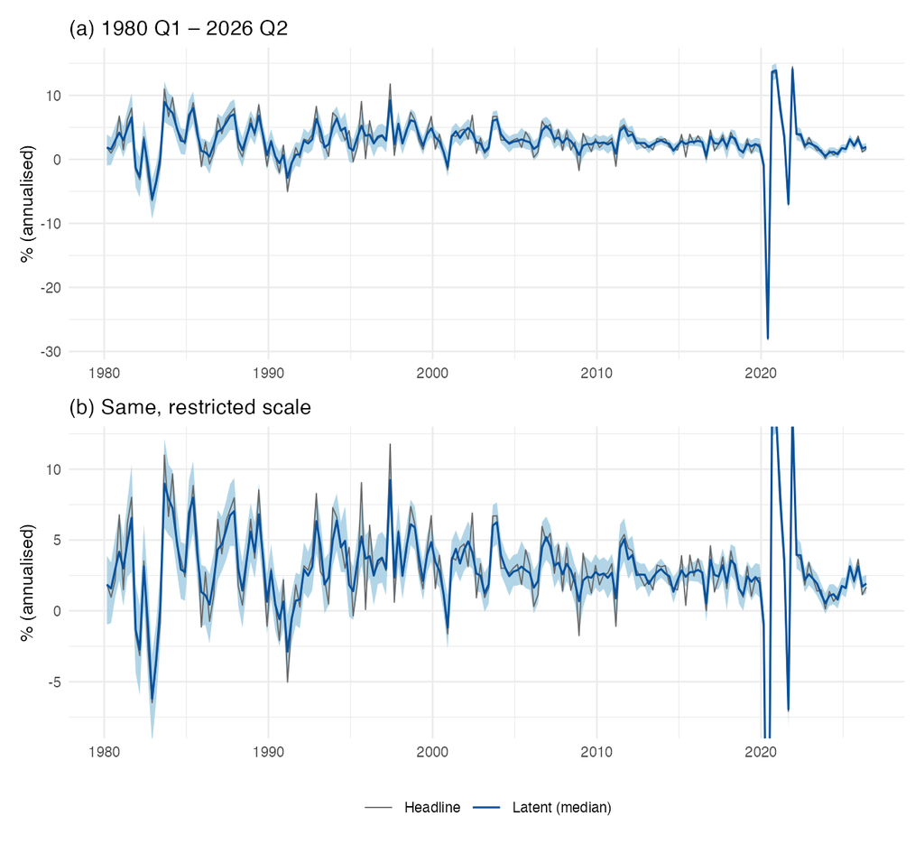

Figure 1: Latent growth (m13, 1980 sample; posterior median and 90% band) and headline growth (mean of E, I and P), annualised per cent. Panel (b) restricts the vertical axis to −8 to 12, so 2020 Q2 and Q3 are off the scale.

Figure 1 shows the latent path against headline growth. The latent series follows the headline’s cycle but removes much of its quarter-to-quarter noise. The 90% band is wide: its average width is 3.4 percentage points before 2020 (0.84 points quarter-on-quarter). That is comparable to the quarter-to-quarter movements of the headline itself. On average the posterior median differs from the headline by 0.84 points. Through the COVID quarters the latent series follows the headline closely: −27.9 [−29.0, −26.8] in 2020 Q2, against a headline of −28.1. The model attributes the collapse to real activity because the three measures agreed, and because latent SV lets the latent innovation variance jump.

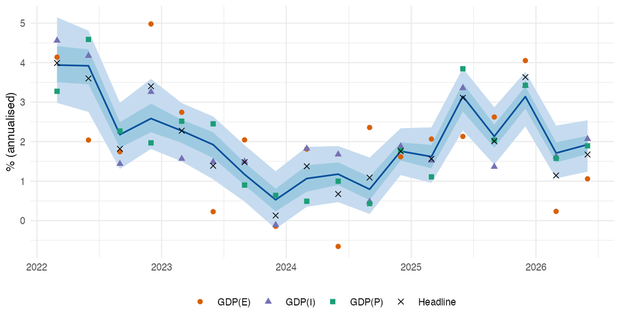

Figure 2: Recent quarters (2022 Q1 – 2026 Q2): latent growth (m13, 1980 sample; median, 50% and 90% bands), the three measures and the headline, annualised per cent. Divide by four for quarter-on-quarter rates.

Figure 2 shows the most recent quarters. For 2026 Q2 the latent median is 1.93 per cent annualised [1.24, 2.54], or 0.48 per cent quarter-on-quarter [0.31, 0.64]. The headline is 0.42 per cent quarter-on-quarter. The published estimate from the continuous-integration run is 0.48 [0.31, 0.63]. In this quarter GDP(E) (0.26 per cent) is weaker than GDP(I) and GDP(P) (0.52 and 0.47), and the latent median is above the headline.

## 7.3 Latent volatility

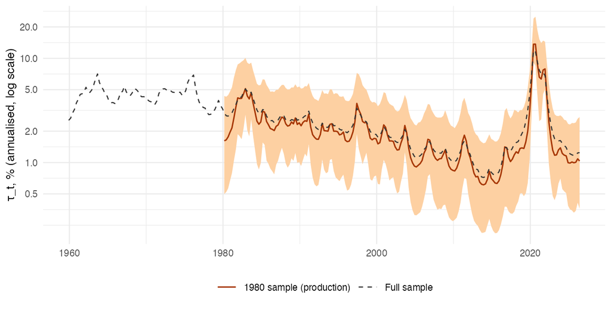

Figure 3: Latent innovation standard deviation $\tau_t = e^{g_t/2}$, annualised: posterior median and 90% band from the 1980-sample production fit, and the full-sample fit’s median (dashed). Log scale.

Table 5: Latent innovation sd $\tau_t$ by decade: posterior median and 90% interval of each decade’s average of $\tau_t$, annualised. The 2020s cover 2020 Q1–2026 Q2.

| Decade | 1980 sample | Full sample |
| --- | --- | --- |
| 1960s | – | 4.89 [3.71, 6.43] |
| 1970s | – | 4.63 [3.37, 6.17] |
| 1980s | 3.12 [2.38, 4.10] | 3.40 [2.66, 4.38] |
| 1990s | 2.36 [1.74, 3.14] | 2.51 [1.92, 3.26] |
| 2000s | 1.53 [1.12, 2.06] | 1.60 [1.18, 2.13] |
| 2010s | 1.25 [0.80, 1.80] | 1.43 [0.97, 2.01] |
| 2020s | 3.98 [3.08, 5.53] | 4.04 [3.15, 5.36] |

Figure 3 and Table 5 show the latent volatility path. The decade average of $\tau_t$ falls from 3.12 in the 1980s to 1.53 in the 2000s and 1.25 in the 2010s. It rises to 13.7 [9.1, 24.1] in 2020 Q2 and is 1.03 in 2026 Q2. The full-sample fit adds the 1960s (4.89) and 1970s (4.63). For comparison, m12, which has the same structure but a constant latent standard deviation, estimates that constant at 2.15 [1.82, 2.53] on the 1980 sample and 3.99 [3.66, 4.34] on the full sample. (On the 1980 sample m12’s constant is pulled down because that fit treats 2020 Q2 as measurement error; Section 8.1.) On either sample a constant latent standard deviation is too large for the 2000s and 2010s and far too small for 2020. This is the source of m13’s predictive gain (Section 7.7). The decline is consistent with the international evidence of lower output volatility since the mid-1980s (McConnell and Perez-Quiros 2000; Stock and Watson 2002). The two samples give similar paths; the 1980 fit has a lower long-run level ($\tau$ 1.81 against 2.47) and less persistent, more variable latent volatility.

## 7.4 Measurement-error volatility

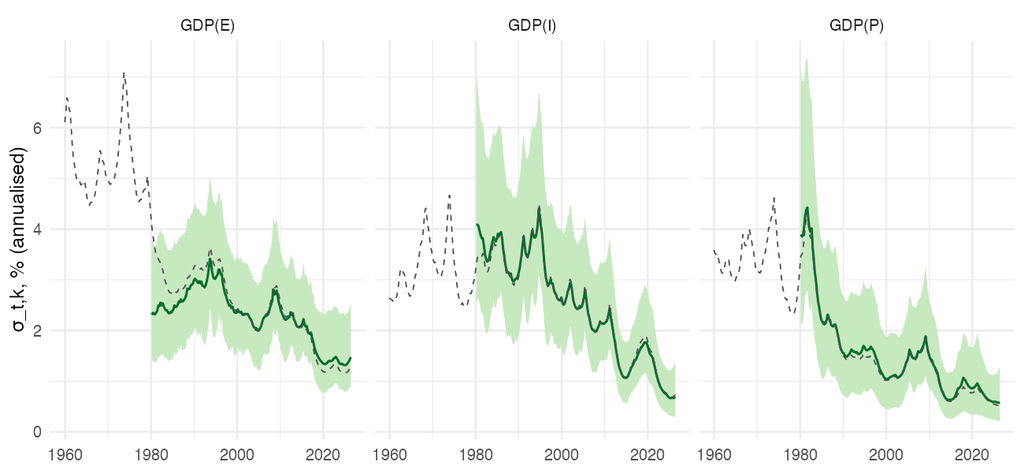

Figure 4: Measurement-error innovation standard deviations $\sigma_{t,k} = e^{h_{t,k}/2}$, annualised: posterior median and 90% band from the 1980-sample production fit; dashed line, full-sample fit’s median.

Figure 4 shows the innovation standard deviations of the three measurement errors. All three fall over the sample. On the 1980 fit they are 2.31, 4.08 and 3.90 (E, I, P) in 1980 Q1, and 1.47, 0.69 and 0.58 in 2026 Q2. On the full sample the expenditure error peaks at 7.1 in 1973 Q3. The COVID quarters show little increase in measurement-error volatility in m13: the expenditure-side innovation standard deviation is 1.35 in 2019 Q4 and 1.34 in 2020 Q2. The collapse is attributed to latent growth. The bands are wide, especially early in the sample.

## 7.5 How much of headline variance is measurement error?

Table 6: Variance of latent growth relative to headline growth: per-draw ratio $\mathrm{var}_t(\mu_t^{(s)})/\mathrm{var}_t(\bar y_t)$, posterior median and 90% interval. ‘Excl. COVID’ drops 2020 Q1–2021 Q1. The last column is the ratio for the posterior-median path, which understates latent variance. m8 and m10 use hours data and start in 1978 Q4 on the full sample; their full-sample column is over 1978 Q4–2026 Q2.

| Model | Full fit, whole sample | 1980 fit, 1980–2026 | 1980 fit, excl. COVID | 1980 fit, median path |
| --- | --- | --- | --- | --- |
| m1 | 0.79 [0.71, 0.86] | 0.85 [0.77, 0.94] | 0.92 [0.82, 1.03] | 0.74 |
| m2 | 0.79 [0.71, 0.86] | 0.85 [0.77, 0.94] | 0.93 [0.83, 1.04] | 0.74 |
| m3 | 0.83 [0.59, 0.92] | 0.89 [0.72, 0.98] | 0.95 [0.82, 1.04] | 0.80 |
| m4 | 0.80 [0.73, 0.88] | 0.33 [0.25, 0.42] | 0.55 [0.44, 0.68] | 0.26 |
| m5 | 0.78 [0.71, 0.86] | 0.85 [0.77, 0.93] | 0.93 [0.83, 1.03] | 0.75 |
| m6 | 0.78 [0.70, 0.86] | 0.85 [0.76, 0.94] | 0.93 [0.82, 1.04] | 0.73 |
| m7 | 0.61 [0.54, 0.68] | 0.51 [0.42, 0.58] | 0.78 [0.67, 0.89] | 0.41 |
| m8 | 0.85 [0.77, 0.93] | 0.85 [0.77, 0.94] | 0.85 [0.75, 0.95] | 0.76 |
| m9 | 0.79 [0.71, 0.87] | 0.32 [0.24, 0.41] | 0.55 [0.41, 0.68] | 0.26 |
| m10 | 0.75 [0.68, 0.82] | 0.78 [0.72, 0.85] | 0.61 [0.50, 0.72] | 0.72 |
| m12 | 0.78 [0.71, 0.85] | 0.37 [0.30, 0.46] | 0.61 [0.50, 0.73] | 0.31 |
| m13 | 0.79 [0.71, 0.89] | 0.87 [0.81, 0.94] | 0.78 [0.67, 0.88] | 0.80 |

For each posterior draw $s$ we compute $\operatorname{var}_t(\mu^{(s)}_t)/\operatorname{var}_t(\bar y_t)$ over a window and report the distribution across draws. One minus this ratio is a rough measure of the share of headline variance that is measurement error. It is not an exact decomposition, because latent growth and the average error need not be uncorrelated in a given sample.

On the 1980 sample, m13’s ratio is 0.872 [0.811, 0.938]. By this measure about an eighth of headline variance since 1980 is measurement error. Excluding 2020 Q1 to 2021 Q1 the ratio is 0.776 [0.675, 0.883], about a fifth. The COVID quarters raise the ratio because they add a large common movement that the model assigns to latent growth. On the full sample the ratio is 0.790 (0.731 excluding COVID). The difference between the samples is almost entirely a matter of which quarters are covered, not of the estimates. Restricted to 1980 Q1 to 2026 Q2, the full-sample fit gives 0.883 (0.793 excluding COVID).

**Per-draw ratios, not the ratio of a summary path.** The posterior median or mean path averages over draws and is smoother than any plausible single path. Its variance understates the variance of latent growth. For m13 on the 1980 sample the median path’s ratio is 0.800 against a per-draw median of 0.872. On the full sample the gap is wider for some models: m12’s median path gives 0.686 against 0.779. An earlier version of this project reported mean-path ratios of about 0.65 and concluded that measured growth overstated true variance by a third. That conclusion was withdrawn.

**The ratio depends on the model, and the comparison does not test it.** On the full sample the three-measure models other than m7 give 0.78 to 0.83. On the 1980 sample, m4, m9 and m12 give 0.32 to 0.37. That is a specification failure, discussed in Section 8.1, not a finding. Scores and splits do not line up. m7 and m1 cannot be told apart by score on the full sample (m7 − m1 +18.1, z 1.08), yet their ratios are 0.61 and 0.79. Conversely, the ranking by score need not match the ranking by ratio. Over 1978 Q4 to 2026 Q2 excluding 2020 Q1 to 2021 Q1, the full-sample m13 gives 0.75, m12 0.88 and m10 (with hours) 0.56, although m13 scores better than both. With a time-varying latent variance, disagreement among the measures in a quiet period is attributed more to measurement error. Predictive scores evaluate forecasts of the observed measures. They do not identify the split between signal and noise, which rests on the model’s structure.

## 7.6 Model checking: prior and posterior predictive checks

Table 7: Predictive checks of m13 (1980 sample). Observed: statistic of the data, 1980 Q1–2026 Q2, annualised units. Cells give the median and 90% interval of the replicated statistic. Full: series simulated from posterior hyperparameters with a fresh latent history (1,000 draws). Conditional: measurement errors simulated given posterior draws of the latent path and the error log-variances. p: share of replications at least as large as the observed value.

| Statistic | Observed | Full replication | Conditional replication |
| --- | --- | --- | --- |
| sd, headline | 3.88 | 4.20 [2.61, 11.42]; p 0.59 | 3.95 [3.74, 4.17]; p 0.71 |
| sd, headline, pre-2020 | 2.84 | 4.13 [2.57, 12.02]; p 0.90 | 2.95 [2.66, 3.25]; p 0.73 |
| sd, GDP(E) | 4.46 | 4.50 [3.07, 9.41]; p 0.51 | 4.53 [4.20, 4.94]; p 0.65 |
| sd, GDP(P) | 4.09 | 4.64 [2.69, 16.75]; p 0.62 | 4.10 [3.82, 4.46]; p 0.53 |
| $\rho_1$, headline | 0.06 | 0.17 [−0.20, 0.49]; p 0.68 | 0.03 [−0.05, 0.11]; p 0.27 |
| $\rho_1$, GDP(P) | 0.11 | 0.16 [−0.23, 0.48]; p 0.60 | 0.04 [−0.08, 0.14]; p 0.12 |
| sd, E − I | 3.88 | 4.27 [2.57, 12.29]; p 0.62 | 3.95 [3.34, 4.66]; p 0.57 |
| sd, E − P | 3.26 | 3.83 [2.42, 14.66]; p 0.70 | 3.34 [2.87, 3.92]; p 0.60 |
| $\rho_1$, E − I | −0.44 | −0.38 [−0.55, −0.19]; p 0.69 | −0.38 [−0.54, −0.22]; p 0.70 |
| $\rho_1$, E − P | −0.36 | −0.32 [−0.52, −0.06]; p 0.60 | −0.35 [−0.51, −0.18]; p 0.53 |
| corr(E, I) | 0.64 | 0.58 [0.17, 0.90]; p 0.40 | 0.64 [0.54, 0.73]; p 0.51 |
| min, headline | −28.12 | −13.34 [−54.87, −5.14]; p 0.84 | −27.99 [−29.77, −26.12]; p 0.54 |
| max, headline | 14.44 | 18.79 [10.40, 59.14]; p 0.74 | 14.88 [13.75, 16.36]; p 0.72 |
| quarters with headline < −4 | 4.00 | 9.00 [1.00, 31.00]; p 0.82 | 5.00 [3.00, 7.00]; p 0.86 |
| sd, E − I, 1980s | 4.60 | 3.87 [2.04, 11.32]; p 0.34 | 4.77 [3.57, 6.27]; p 0.58 |
| sd, E − I, 2010s | 3.18 | 4.00 [2.13, 13.34]; p 0.71 | 2.85 [2.15, 3.89]; p 0.26 |

No prior predictive or posterior predictive checks were part of the original research suite. We ran both for the production model after the comparison was complete (`paper/ppc_m13.R`). Replicated series are simulated in R from the model equations; no Stan model is refitted. The fit’s own replicated data are not used, because they condition on the observed value of the previous quarter.

**Prior predictive.** Over 4,000 draws from the priors, the long-run mean of latent growth has a prior median of 2.8 per cent a year (90% interval [−0.2, 14.7]). The standard deviation of simulated headline growth has a prior median of 4.9 [2.5, 14.6], against 3.9 in the data. The long-run expenditure-error standard deviation is 3.1 [1.3, 8.0], and $\tau$ is 2.7 [1.2, 6.3]. The priors are therefore centred on plausible values. They are also heavy-tailed: 10% of prior draws give a headline standard deviation above 10, and the 99th percentile of the largest absolute quarterly growth rate is 648 per cent annualised. The observed statistics all fall well inside the prior predictive range (the observed headline standard deviation is at prior percentile 30). The priors do not rule out the data, but they put noticeable mass on implausibly volatile economies.

**What drives the prior tails.** We simulated 20,000 further prior draws (`paper/prior_candidates.R`) and asked which parameters the extreme draws have in common. Two features dominate. The first is the stationary standard deviation of a log-variance, $s = \omega/\sqrt{1-\phi^2}$. Under Uniform(−1, 1) persistence and a half-N(0, 0.5) innovation scale, $|\phi|$ near one with a moderate $\omega$ makes $s$ large, and $e^{h/2}$ then ranges over orders of magnitude. At least one of the four log-variances has $s > 2$ in 13% of all draws but in 76% of the draws whose largest absolute headline growth exceeds 100 per cent. The second is $\rho$ near one, which inflates both $c/(1-\rho)$ and the latent variance $\tau^2/(1-\rho^2)$: $\rho > 0.9$ in 5% of all draws and 26% of those extreme draws. Conditioning on the draws shows the size of each effect. The 99th percentile of the largest absolute headline growth is 579 in all draws, 467 given $\rho \le 0.9$, 105 given all $s \le 2$, and 63 given both. The levels $\mu_g$ and $\mu_{h,k}$ matter much less.

- **C1** changes only the latent mean and persistence. It puts RDP 2014-12’s prior on persistence, $\rho \sim$ Beta with mean 0.5 and standard deviation 0.2, that is Beta(2.625, 2.625) on (0, 1), and m1’s N(3, 2) prior on the long-run mean $\bar\mu$ instead of a prior on $c$, with $c = \bar\mu(1-\rho)$. Because $\bar\mu$ is then the sampled parameter, no Jacobian adjustment is needed.
- **C2** adds the prior of Kim et al. (1998), $(\phi+1)/2 \sim$ Beta(20, 1.5), on the persistence of every log-variance, with m13’s $\omega$ priors.
- **C3** instead puts the scale prior on the stationary standard deviation of each log-variance, $s \sim$ half-N(0, 1), keeps $\phi \sim$ Uniform(−1, 1), and derives $\omega = s\sqrt{1-\phi^2}$. At $|\phi| = 0.87$ this is m13’s half-N(0, 0.5) prior on $\omega$; as $|\phi| \to 1$ the log-variance can stay persistent without its range exploding.

Table 8: Prior predictive simulation of m13’s priors and three candidate sets (20,000 draws each, 1980 Q1–2026 Q2, annualised per cent). Cells give the median and 90% interval, or the 99th percentile. ‘Observed percentiles’ is the range, over six statistics (standard deviation, mean, largest absolute value and first-order autocorrelation of headline growth; standard deviation of E − I; pre-2020 standard deviation of headline growth), of the prior predictive percentile of the observed value. Target: T1 sd interval within [1, 15]; T2 99th percentile of max |headline| ≤ 100; T3 mean interval within [−3, 9]; T4 all observed percentiles within [2.5, 97.5].

| Prior | sd, headline | mean, headline | max \|headline\|, 99th pct | share sd > 10 | Observed percentiles | T1 / T2 / T3 / T4 |
| --- | --- | --- | --- | --- | --- | --- |
| m13 | 4.9 [2.5, 14.4] | 2.9 [−0.7, 16.3] | 579 | 10% | 9–76 | yes / no / no / yes |
| C1: Beta $\rho$, N(3, 2) on $\bar\mu$ | 4.8 [2.5, 13.7] | 3.0 [−0.8, 6.9] | 520 | 9% | 9–81 | yes / no / yes / yes |
| C2: C1 + Beta(20, 1.5) on $(\phi+1)/2$ | 5.7 [2.7, 29.1] | 3.0 [−1.3, 7.2] | 1,747 | 20% | 6–63 | no / no / yes / yes |
| C3: C1 + half-N(0, 1) on stationary sd | 5.3 [2.8, 14.0] | 3.0 [−0.8, 6.9] | 172 | 12% | 6–70 | yes / no / yes / yes |

Table 8 gives the results. C1 brings the mean within bounds but leaves the variance tails almost as they were. The Kim–Shephard–Chib prior makes them worse (99th percentile 1,747): it concentrates persistence near one, and with m13’s innovation scale that inflates the stationary variance. Kim et al. (1998) pair it with a prior that keeps the volatility of volatility small. C3 cuts the 99th percentile from 579 to 172 and meets T1, T3 and T4, but not T2. No candidate met the whole target, so by the fallback rule we chose C3. Its remaining tail comes mainly from the latent log-variance: in 70% of its draws with a headline above 100 per cent the latent path itself exceeds 100 per cent, and 78% have a stationary log-variance standard deviation above 2. The choice was made from the prior predictive alone and was not revisited after the fit. C3 is implemented as `stan/m13_tight_priors.stan`, which has m13’s likelihood unchanged (`tests/test_m13_tight.R`). It is a research variant; the published estimate still uses m13’s priors.

**Posterior predictive.** Table 7 compares statistics of the data with their replicated distributions. In the full replication, which draws a fresh latent and volatility history, every posterior predictive p-value lies between 0.34 and 0.90. The model reproduces the negative first-order autocorrelation of the differences between measures (E − I: observed −0.44, replicated median −0.38), the correlation between the measures and the size of the extremes. Its replications are more volatile than the data in typical quarters: the observed pre-2020 headline standard deviation, 2.84, is below 90% of replications. That is expected of a model whose latent volatility can wander: a fresh history rarely reproduces the long calm of the 2000s and 2010s. In the conditional replication, which keeps the posterior latent path and error log-variances, the 90% pointwise intervals cover 97% (E), 94% (I) and 99% (P) of the observations, and the 50% intervals 53%, 54% and 72%. Production is over-covered: given the latent path, the model’s production-error variance is somewhat too large, or the latent path absorbs part of the production signal. The weakest conditional check is the autocorrelation of GDP(P) (p = 0.12): the observed value, 0.11, is above most replications. None of these checks indicates a gross misfit. They are in-sample checks and use the data twice.

## 7.7 Model comparison

Table 9: PSIS-LFO-CV scores of the three-measure models: sum of one-step-ahead log predictive densities over 146 targets (1990 Q1–2026 Q2), annualised units. Δ is the difference from m13 with i.i.d. and Newey-West (lag 8) standard errors. MCSE: Monte Carlo SE of the particle filter (4 passes); ‘exact’ for Kalman-filter models. Fits: initial fit plus refits, with the number retried (passed only after a new seed) in brackets.

| Model | elpd, full | Δ, full | SE iid/NW | MCSE | fits | elpd, 1980 | Δ, 1980 | SE iid/NW | MCSE | fits |
| --- | --- | --- | --- | --- | --- | --- | --- | --- | --- | --- |
| m13 | −1,045.8 | 0.0 | – | 0.22 | 6 (0) | −1,039.5 | 0.0 | – | 0.02 | 8 (0) |
| m12 | −1,105.5 | −59.6 | 24.7/28.9 | 0.20 | 8 (1) | −1,096.9 | −57.4 | 27.2/36.6 | 0.75 | 7 (0) |
| m9 | −1,122.2 | −76.4 | 21.8/24.8 | 0.31 | 8 (2) | −1,117.5 | −78.0 | 30.6/40.4 | 0.60 | 7 (0) |
| m4 | −1,123.7 | −77.9 | 21.9/23.7 | 0.02 | 7 (0) | −1,121.2 | −81.7 | 31.1/42.3 | 0.91 | 6 (1) |
| m5 | −1,168.8 | −123.0 | 15.3/25.7 | exact | 6 (0) | −1,134.2 | −94.7 | 33.8/42.9 | exact | 6 (0) |
| m7 | −1,177.5 | −131.7 | 12.2/20.7 | exact | 5 (0) | −1,120.4 | −80.9 | 12.2/19.0 | exact | 7 (0) |
| m6 | −1,195.6 | −149.8 | 15.5/25.4 | exact | 4 (0) | −1,156.4 | −116.9 | 34.3/43.7 | exact | 5 (0) |
| m1 | −1,195.7 | −149.8 | 15.8/25.2 | exact | 5 (0) | −1,149.4 | −109.9 | 31.8/35.7 | exact | 5 (0) |
| m3 | −1,195.9 | −150.1 | 15.5/25.8 | exact | 4 (0) | −1,158.3 | −118.8 | 36.5/45.0 | exact | 6 (0) |
| m2 | −1,196.2 | −150.4 | 15.6/25.6 | exact | 5 (0) | −1,154.6 | −115.1 | 33.8/42.9 | exact | 6 (0) |

Table 9 reports the scores of the ten three-measure models on both samples. The ranking on the full sample is m13, m12, m9, m4, m5, m7, m6, m1, m3, m2. On the 1980 sample it is m13, m12, m9, m7, m4, m5, m1, m2, m6, m3. On the full sample three groups stand out: m13; the measurement-SV models m12, m9 and m4; and the constant-variance models. On the 1980 sample m7 joins the middle group, and the constant-variance models move closer to it. The scores are summed over 146 quarters, so a difference of 10 nats is about 0.07 nats per quarter.

Table 10: Key score differences a − b (nats over 146 targets), with i.i.d. and Newey-West SEs and the Newey-West z. Most pairs add one feature; m12 − m5 adds two (measurement SV and the E–I-only structure) and m13 − m5 three. ‘Not nested’ pairs differ in more than one way.

| a − b | Feature | Full sample | 1980 sample |
| --- | --- | --- | --- |
| m5−m2 | serial errors (constant variance) | +27.4 (2.9/2.0), z 14.05 | +20.4 (3.6/2.2), z 9.40 |
| m12−m9 | serial errors (with measurement SV) | +16.8 (6.7/6.1), z 2.74 | +20.6 (7.9/5.5), z 3.72 |
| m4−m2 | measurement SV (independent errors) | +72.5 (12.1/19.1), z 3.79 | +33.4 (9.4/15.8), z 2.11 |
| m9−m6 | measurement SV (E–I correlation) | +73.3 (12.2/19.9), z 3.69 | +38.9 (9.7/15.1), z 2.58 |
| m12−m5 | measurement SV + E–I, with serial errors | +63.4 (14.3/20.7), z 3.06 | +37.3 (13.3/15.1), z 2.47 |
| m13−m12 | latent SV | +59.6 (24.7/28.9), z 2.06 | +57.4 (27.2/36.6), z 1.57 |
| m9−m4 | E–I-only restriction (with SV) | +1.5 (1.5/2.2), z 0.68 | +3.7 (1.6/2.4), z 1.58 |
| m6−m2 | E–I-only restriction (constant) | +0.7 (0.3/0.4), z 1.74 | −1.8 (0.9/1.0), z −1.76 |
| m7−m1 | COVID variance scale | +18.1 (18.4/16.7), z 1.08 | +29.0 (33.8/28.4), z 1.02 |
| m13−m5 | all three features | +123.0 (15.3/25.7), z 4.78 | +94.7 (33.8/42.9), z 2.20 |
| m9−m5 | not nested: adds SV, drops serial errors | +46.6 (12.5/19.7), z 2.37 | +16.7 (9.3/14.7), z 1.13 |
| m4−m1 | not nested: adds SV and latent AR(1) | +71.9 (12.0/19.4), z 3.71 | +28.2 (10.4/19.4), z 1.46 |

Table 10 isolates each feature by comparing nested models.

**Serially correlated measurement errors: the robust gain.** Adding AR(1) errors to the constant-variance model improves the score by +27.4 nats on the full sample and +20.4 on the 1980 sample. The Newey-West z-statistics, 14.0 and 9.4, are the largest in the comparison. Adding them to the measurement-SV model (m12 against m9) gives +16.8 (z 2.74) and +20.6 (z 3.72). m5 − m2 is positive in every sub-period on both samples (Table 11). m12 − m9 is positive in every sub-period on the 1980 sample, but on the full sample it is −4.2 in 2020. Serial correlation is therefore the feature whose gain holds on both samples and with or without SV; only in the constant-variance comparison does it hold in every sub-period on both.

**SV in the measurement errors: a real gain that roughly halves from 1980.** The two comparisons that add only measurement SV are m4 − m2 (independent errors) and m9 − m6 (E–I correlation). On the full sample they are +72.5 (z 3.79) and +73.3 (z 3.69). On the 1980 sample they are +33.4 (z 2.11) and +38.9 (z 2.58). The reason is discussed in Section 8.1. Before 2020 the gains on the 1980 sample are +19.4 (z 3.02) and +21.4 (z 3.22). On both samples they are largest in 2008–19 and 2023–26, after measurement-error variance had fallen (Figure 4).

**SV in latent growth: first, but by a thin and post hoc margin.** m13 − m12 is +59.6 nats on the full sample (SE 24.7 i.i.d., 28.9 Newey-West; z 2.06). On the 1980 sample it is +57.4 (SE 27.2 / 36.6; z 1.57). One quarter dominates the uncertainty. 2020 Q2 alone contributes +23.7 nats on the full sample and +25.6 on the 1980 sample: m12’s constant latent variance cannot accommodate the collapse. Outside 2020 Q2 to 2021 Q1 the full-sample gain is +28.5 (NW SE 6.0); before 2020 it is +20.1 (z 4.1). m13 is ahead in 122 of 146 quarters. Outside 2020 the gain per quarter grows over the window, as latent volatility falls further below m12’s constant. On the 1980 sample the pre-2020 gain is only +6.4 (z 2.31), and m13 is ahead in 107 quarters. Excluding all of 2020 to 2022, the gain is +27.1 (z 4.59) on the full sample and +12.7 (z 2.59) on the 1980 sample.

m13 was proposed after the re-specified m10, which has latent SV, had been scored on the same window and had beaten m12 on the GDP-only target. m13 is therefore a second latent-SV specification evaluated on the same data. Counting only those two tries, a Bonferroni-adjusted two-sided 5% bar is z ≈ 2.24, which 2.06 does not meet. That bar is a lower bound on the correction: the old m10, the re-specified m10, m12 and m13 were all scored on the same 146 targets. The direction of the evidence is clear: latent volatility has changed a great deal over the sample (Figure 3). Its strength as a test of predictive improvement is modest.

**The structural restriction is predictively neutral.** m9 − m4 is +1.5 (z 0.68) on the full sample, and m6 − m2 is +0.66. On the 1980 sample they are +3.7 and −1.77. m9 − m4 on the 1980 sample is within the particle-filter uncertainty of these models in 2020 Q2 (Section 8.5) and falls to +0.46 with first refit attempts only. We keep the restriction because it reflects how the measures are built, not because the data favour it.

**COVID variance scale.** m7 − m1 is +18.1 (z 1.08) on the full sample. Its gain comes from 2020, and m7 knows in advance which quarters to scale. On the full sample m7’s 2020 Q2 scale factor is 7.7 [4.7, 14.3], while the scale factors for the other three quarters have medians of 0.51, 0.59 and 0.93. m7 therefore treats essentially all of the 2020 Q2 collapse as measurement error: its latent growth in 2020 Q2 has posterior mean +1.7 on the full sample and +3.6 on the 1980 sample, against a headline of −28.1. Its variance ratio, 0.61, is the lowest of the full-sample models.

Table 11: Score differences by sub-period (nats). Each cell gives the full-sample run / the 1980-sample run. ‘Excl. COVID’ drops 2020 Q2–2021 Q1. Newey-West SEs for the longer periods are in the text and in output/sample_1980/tables/lfo_full_vs_sample.csv.

| Period | m5 − m2 | m12 − m9 | m4 − m2 | m9 − m6 | m9 − m4 | m13 − m12 |
| --- | --- | --- | --- | --- | --- | --- |
| 1990–99 | 7.6/5.3 | 6.7/5.7 | 5.9/1.6 | 5.6/2.0 | −0.4/0.1 | 1.3/−0.4 |
| 2000–07 | 7.1/5.0 | 9.2/6.0 | 12.0/3.4 | 13.3/3.7 | 1.3/0.5 | 4.0/0.4 |
| 2008–19 | 8.4/6.8 | 3.9/2.9 | 31.5/14.5 | 33.6/15.7 | 2.3/0.5 | 14.8/6.4 |
| 2020 | 0.2/0.3 | −4.2/5.2 | −7.5/4.1 | −8.8/6.4 | −1.1/1.3 | 30.1/32.4 |
| 2021–22 | 1.3/1.0 | 0.4/0.5 | 5.3/−8.8 | 4.3/−7.4 | −0.9/1.5 | 2.5/12.3 |
| 2023–26 | 2.7/1.9 | 0.7/0.4 | 25.2/18.6 | 25.4/18.4 | 0.3/−0.1 | 7.0/6.4 |
| pre-2020 | 23.1/17.2 | 19.9/14.5 | 49.5/19.4 | 52.5/21.4 | 3.2/1.1 | 20.1/6.4 |
| excl. COVID | 27.0/20.0 | 20.5/16.4 | 81.6/30.2 | 83.6/33.4 | 2.3/2.3 | 28.5/22.6 |
| all 146 | 27.4/20.4 | 16.8/20.6 | 72.5/33.4 | 73.3/38.9 | 1.5/3.7 | 59.6/57.4 |

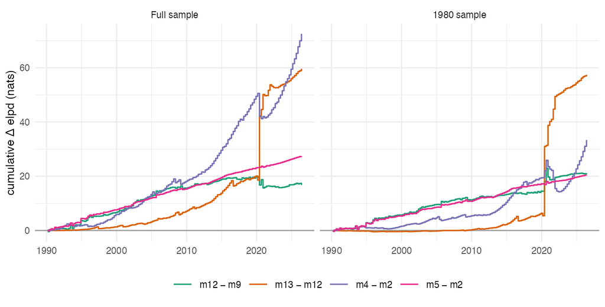

Figure 5: Cumulative score differences over the 146 LFO targets (nats). Left: full-sample run (training from 1959 Q4). Right: 1980-sample run (training from 1980 Q1).

Table 11 and Figure 5 show where the differences arise. The serial-correlation gain (m5 − m2) accumulates steadily, mostly in the 1990s and 2000s. The measurement-SV gain (m4 − m2) builds from 2000 and is largest in 2008–19 and 2023–26. It falls back in 2020 on the full sample. The latent-SV gain (m13 − m12) is small in the 1990s, grows through the 2010s and jumps in 2020 Q2. On the 1980 sample m12 is slightly ahead of m13 in 1990–99 (−0.4, NW z −2.50).

**Labour-market models.** On the hours subsample the re-specified m10 is ahead of m8, which has constant variances, by +124.2 nats on the joint four-signal target (z 1.92). This gain is post hoc in the sense above. On the GDP-only target, $\log p(y^{E,I,P}_t \mid y_{1:t-1})$ with hours in the past but not in the target, m13 is ahead of m10 by +12.6 (z 2.30) and of the mixed-frequency m11 by +67.5 (z 3.67). These gaps do not measure the value of labour data. m10 has neither AR(1) errors nor the E–I correlation, m11 has no SV, and no m13-plus-hours model was fitted. m11 also conditions on employment inside the target quarter, which is released before GDP.

# 8 Robustness

## 8.1 Starting in 1980 instead of 1959

The 146 targets are identical in the two runs. What differs is the training data: 40 against 121 quarters before the first target, and no 1960s or 1970s. Each change therefore mixes two effects: dropping data whose errors may be unrepresentative, and estimating parameters from less history.

**What survives.** m13 is first on every target on both samples. Serially correlated errors help on both samples, with and without SV; in the constant-variance comparison they help in every sub-period (Table 11). m13’s AR(1) coefficients barely move (Table 4). The structural restriction is still unsupported. Production remains the cleanest measure in every specification. m10’s lead over m8 is essentially unchanged (+119.6, z 1.84). m13’s latent path is almost the same: on the common quarters the posterior mean paths have correlation 0.9985 and differ by 0.13 points on average (at most 1.03).

**What weakens.** The latent-SV evidence: m13 − m12 is +57.4 with z 1.57. Newey-West z-statistics at lags 4, 8, 12 and 16 are 1.78, 1.57, 1.49, 1.45 (full sample 2.17, 2.06, 2.05, 2.05). The z ≥ 2 condition that was used to switch production to m13 (Section 12) would not be met on this sample. Part of the 1980 margin is in 2021–22 (+12.3, against +2.5 on the full sample). In that period m12’s 1980 fit mishandles the aftermath of COVID (below), so part of the margin scores that failure rather than a general gain. Measurement SV also weakens: the nested gains roughly halve (Table 10).

**Why the measurement-SV gain halves.** Before 2020 every model scores better when trained from 1980, but the constant-variance models gain about twice as much. Their error variances, GDP(E)’s above all, are no longer inflated by the noisy early decades. The pre-2020 change from the later start is +55.2 for m2 against +25.2 for m4. In the constant-variance models the expenditure error standard deviation falls from 4.09 to 2.55 (m2). That is the pattern RDP 2014-12’s argument for a 1980 start predicts. About half of the full-sample measurement-SV gain came from pre-1980 training data. The rest survives the later start, but less cleanly: before 2020 the nested gains are +19.4 and +21.4 on the 1980 sample against +49.5 and +52.5 on the full sample, and the 1980 fits of m4 and m9 lose to the constant-variance models in 2021–22 (−8.8 and −7.4).

**What fails: m4, m9 and m12 on COVID.** On the 1980 sample these three models, which have measurement SV but a constant latent variance, treat the 2020 Q2 collapse as a common measurement error (Figure 6). Their latent growth in 2020 Q2 is 0.2 (m4), 0.2 (m9) and −1.0 (m12), against −27.2, −27.2 and −27.1 on the full sample and a headline of −28.1. Their variance ratios fall to 0.32–0.37. This is the same failure as the old m10’s mode A. In m12 the expenditure-volatility persistence collapses to −0.10 [−0.65, 0.80], against 0.98 [0.93, 1.00] on the full sample, while its volatility of volatility rises to 0.79. Expenditure-side SV then behaves as i.i.d. heavy-tailed noise that can absorb one huge quarter. The prior on that persistence is Uniform(−1, 1), so a posterior centred near zero with a wide interval is close to the prior. We checked that this is not a stranded mode. For each of m4, m9 and m12, four extra chains were started from full-sample draws, where COVID is in latent growth. All twelve chains moved to the measurement-error solution and matched the reference fit. Warmup draws were saved for m4 and m12, and there every chain left the starting region within 8 to 52 warmup iterations. That is evidence about one alternative region, not proof that no other mode exists. m13 and m10, which have latent SV, keep COVID in latent growth on both samples. So, mostly, do the constant-variance models: their latent 2020 Q2 is −24.4 to −23.5 on the 1980 sample.

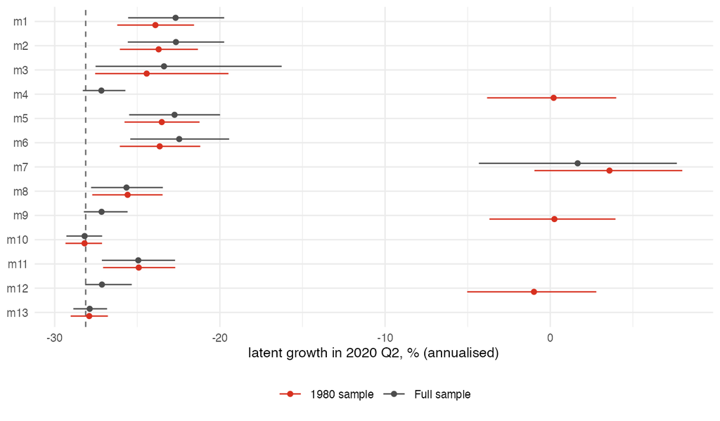

Figure 6: Latent growth in 2020 Q2 by model and sample: posterior mean and 90% interval, annualised per cent. Dashed line: headline growth in 2020 Q2. m11’s value is the quarterly aggregate of its monthly state.

**What changes.** m7 rises from sixth to fourth on the 1980 sample, level with m9 and m4. m13’s variance ratio is higher on the 1980 sample, but only because the window excludes the 1960s and 1970s (Section 7.5).

**Does the later start improve prediction?** m13 trained from 1980 scores +6.3 nats better on the same 146 targets than m13 trained from 1959 (NW SE 3.74, z 1.69). Most of the gain is in 1990–99 (+4.5). These are the targets nearest the dropped data, and they have the shortest 1980 training sets. From 2000 on the gain is +1.8 (z 0.72). For current estimates the start date hardly matters for prediction. The published estimate moved to the 1980 sample on 19 October 2026. That was a decision based on RDP 2014-12’s argument about early measurement errors, not the outcome of a pre-set rule (Section 12).

## 8.2 Prior sensitivity

The posterior median of $\omega_g$ on the full sample (0.61) sits at percentile 78 of its half-N(0, 0.5) prior. On the 1980 sample (0.88) it sits at percentile 92. The prior may therefore restrain it. We refitted the full-sample m13 with a half-N(0, 1) prior; the refit also passed the gate. $\omega_g$ moved from 0.61 [0.42, 0.89] to 0.66 [0.44, 1.02], and $\tau$ from 2.47 to 2.43. The median $\tau_t$ path changed by 1.9% on average (at most 7.4%). The median latent path moved by 0.033 points on average (at most 0.18). The variance ratio went from 0.790 to 0.786. The results are insensitive to this widening.

For this paper the same refit was run on the production sample, 1980 Q1 to 2026 Q2 (`R/fit_m13.R --omega_g_sd=1`). There the prior matters more, because the 1980 posterior of $\omega_g$ sits further into the prior’s tail. The refit passed the production gate (1 divergence, minimum E-BFMI 0.866, maximum hyperparameter R-hat 1.0064, minimum hyperparameter bulk ESS 1,208). $\omega_g$ moved from 0.88 [0.59, 1.26] to 1.02 [0.65, 1.53], $\phi_g$ from 0.83 to 0.79 and $\tau$ from 1.81 to 1.74. The median $\tau_t$ path changed by 4.7% on average (at most 17.7%, in 2019 Q3); 2020 Q2’s $\tau_t$ went from 13.7 to 14.7. The median latent path moved by 0.033 points on average (at most 0.17), and the variance ratio went from 0.872 to 0.871 (0.776 to 0.772 excluding 2020 Q1–2021 Q1). The latent path and the variance ratio are again insensitive. The latent-volatility path is less so: it moves by up to a sixth in some quarters, so statements about $\tau_t$ in individual quarters carry prior uncertainty beyond their posterior intervals. The wider prior was not scored by LFO.

### 8.2.1 Tighter priors

Table 12: m13 with its own priors (the production fit) and with the tighter priors chosen in Section 7.6, both on 1980 Q1–2026 Q2, seed 1 (seed 2 of the variant in the last column). Posterior medians and 90% intervals, annualised units. Variance ratio: per-draw var(μ)/var(headline). $\tau_t$ by decade: posterior median of the decade average. Diagnostics: the production gate (all checks passed for all three fits); time is the wall time of the sampler with four parallel chains on a six-core machine, which also ran other work.

| Quantity | m13 | Tight | Tight, seed 2 |
| --- | --- | --- | --- |
| $\rho$ | 0.39 [0.23, 0.54] | 0.42 [0.25, 0.57] | 0.42 [0.25, 0.57] |
| $\bar\mu$ | 2.62 [2.31, 2.96] | 2.61 [2.28, 2.95] | 2.61 [2.27, 2.94] |
| $\tau = e^{\mu_g/2}$ | 1.81 [1.26, 2.67] | 1.69 [1.20, 2.40] | 1.70 [1.21, 2.41] |
| $\phi_g$ | 0.83 [0.65, 0.94] | 0.77 [0.53, 0.91] | 0.78 [0.54, 0.91] |
| $\omega_g$ | 0.88 [0.59, 1.26] | 1.03 [0.65, 1.56] | 1.02 [0.64, 1.54] |
| $\phi_E$ | 0.95 [0.11, 0.99] | 0.96 [0.53, 1.00] | 0.96 [0.47, 1.00] |
| $\phi_I$ | 0.98 [0.90, 1.00] | 0.98 [0.90, 1.00] | 0.98 [0.91, 1.00] |
| $\phi_P$ | 0.97 [0.88, 1.00] | 0.97 [0.87, 0.99] | 0.97 [0.87, 0.99] |
| $\omega_E$ | 0.23 [0.10, 0.57] | 0.20 [0.08, 0.55] | 0.20 [0.08, 0.56] |
| $\omega_I$ | 0.31 [0.15, 0.53] | 0.27 [0.12, 0.51] | 0.26 [0.12, 0.51] |
| $\omega_P$ | 0.36 [0.17, 0.66] | 0.32 [0.15, 0.65] | 0.32 [0.14, 0.65] |
| $\psi_E$ | −0.43 [−0.54, −0.31] | −0.42 [−0.54, −0.30] | −0.42 [−0.55, −0.30] |
| $\psi_I$ | −0.35 [−0.48, −0.22] | −0.35 [−0.48, −0.23] | −0.36 [−0.48, −0.23] |
| $\psi_P$ | −0.18 [−0.36, 0.02] | −0.19 [−0.37, 0.00] | −0.19 [−0.37, 0.00] |
| $\rho_{EI}$ | 0.09 [−0.08, 0.24] | 0.09 [−0.07, 0.24] | 0.09 [−0.07, 0.24] |
| latent growth, 2026 Q2 | 1.93 [1.24, 2.54] | 1.91 [1.14, 2.56] | 1.91 [1.13, 2.57] |
| latent growth, 2020 Q2 | −27.91 [−29.03, −26.78] | −27.93 [−29.08, −26.80] | −27.92 [−29.04, −26.79] |
| $\tau_t$, 2020 Q2 | 13.67 [9.09, 24.06] | 14.57 [9.29, 27.36] | 14.55 [9.27, 27.07] |
| variance ratio, 1980 Q1–2026 Q2 | 0.872 [0.811, 0.938] | 0.867 [0.802, 0.932] | 0.868 [0.804, 0.933] |
| variance ratio, excl. 2020 Q1–2021 Q1 | 0.776 [0.675, 0.883] | 0.766 [0.664, 0.871] | 0.767 [0.665, 0.874] |
| $\tau_t$, 1980s | 3.12 [2.38, 4.10] | 3.03 [2.26, 4.03] | 3.03 [2.28, 4.02] |
| $\tau_t$, 1990s | 2.36 [1.74, 3.14] | 2.28 [1.66, 3.07] | 2.28 [1.68, 3.06] |
| $\tau_t$, 2000s | 1.53 [1.12, 2.06] | 1.52 [1.10, 2.08] | 1.52 [1.10, 2.05] |
| $\tau_t$, 2010s | 1.25 [0.80, 1.80] | 1.23 [0.80, 1.77] | 1.24 [0.78, 1.76] |
| $\tau_t$, 2020s | 3.98 [3.08, 5.53] | 3.94 [3.02, 5.48] | 3.96 [3.01, 5.48] |
| diagnostics | 0 div; E-BFMI 0.882; R-hat 1.0013; ESS 1,315/882 (phi[1]) | 0 div; E-BFMI 0.838; R-hat 1.0016; ESS 1,597/923 (phi[1]) | 0 div; E-BFMI 0.869; R-hat 1.0030; ESS 1,401/704 (phi[1]) |
| time | 17.5 min | 8.8 min | 12.8 min |

The prior predictive check of Section 7.6 chose a set of tighter priors (C3: a Beta(2.625, 2.625) prior on $\rho$, N(3, 2) on $\bar\mu$, and half-N(0, 1) on the stationary standard deviation of each log-variance). We fitted this variant to the production sample with the production settings and evaluated it with the production gate. It passed on both seeds (Table 12); the two seeds agree as closely as m13’s seeds do (median latent paths 0.015 points apart on average, 0.10 at most). Its sampler took 9 and 13 minutes against 17 and 13 for m13’s two seeds; the machine was shared with other work, so we read this only as “no slower”.

**What does not move.** The latent path, the measurement-error parameters and the variance split are essentially unchanged. The median latent path moves by 0.056 annualised points on average and by at most 0.29 (in 1994 Q3), against a seed-to-seed difference for m13 of 0.016 on average and 0.10 at most. Latent growth in 2026 Q2 is 0.48 per cent quarter-on-quarter (90% interval 0.29 to 0.64), against 0.48 (0.31 to 0.64). The per-draw variance ratio is 0.867 against 0.872, and 0.766 against 0.776 excluding 2020 Q1–2021 Q1. $\rho$, $\bar\mu$, $\psi$ and $\rho_{EI}$ move by a few hundredths at most. In the error block the only visible change is that the long left tail of the expenditure-volatility persistence $\phi_E$ (Section 7) shortens: its 5% point rises from 0.11 to 0.53. The Beta prior’s exclusion of negative $\rho$ does not bind: m13’s 90% interval for $\rho$ is already well inside (0, 1). The posterior predictive checks give the same picture as m13’s (Table 7): in the full replication the p-values lie between 0.33 and 0.88, the observed pre-2020 headline standard deviation is below 88% of replications, and the conditional 90% intervals cover 96%, 94% and 99% of the observations. The replications’ upper tails are thinner: the 95th percentile of the replicated headline standard deviation is 7.9 against 11.4 under m13’s priors.

**What moves.** The latent-volatility block. Latent log-volatility is less persistent and more variable ($\phi_g$ 0.77 [0.53, 0.91] against 0.83 [0.65, 0.94]; $\omega_g$ 1.03 [0.65, 1.56] against 0.88 [0.59, 1.26]), and $\tau$ is a little lower (1.69 against 1.81). The median $\tau_t$ path changes by 5.7% on average and by up to 20% (in 2019 Q3); 2020 Q2’s $\tau_t$ goes from 13.7 to 14.6. The decade averages move by at most 0.09 (Table 12). This is the same direction and size as the half-N(0, 1) prior on $\omega_g$ above, and for the same reason: the prior on the scale of the latent log-variance restrains it. The posterior median of $s_g$, 1.65, is at the 90th percentile of its half-N(0, 1) prior. Statements about $\tau_t$ in single quarters are therefore prior-sensitive at the level of a fifth; the latent path and the variance split are not.

**On RDP 2014-12’s sample.** On 1980 Q1–2013 Q2 (`paper/fit_rdp_sample.R m13_tight`) the variant does not identify latent-volatility persistence any better: $\phi_g$ is 0.95 [−0.29, 0.99] against 0.91 [−0.49, 0.99] under m13’s priors, and $s_g$ is 0.80 [0.25, 1.57]. Without COVID the latent log-variance varies too little for its persistence to be learnt from 134 quarters, and the Uniform(−1, 1) prior on $\phi_g$ was kept. The median latent path moves by 0.049 points on average (at most 0.20) and the variance ratio over 1980–2013 is 0.687 against 0.686. That fit had 0 divergences, minimum E-BFMI 0.87, maximum hyperparameter R-hat 1.0066 (on phi_g) and minimum hyperparameter bulk ESS 698.

The variant was not scored by LFO. Since the latent path and the variance split do not move, and the production model was chosen by LFO under m13’s priors, we see no result here that would change a published number beyond the latent-volatility path. Production keeps m13’s priors.

## 8.3 Seeds

Table 13: Seed robustness of m13: second-seed fits against seed 1. Path differences are in annualised percentage points; $\tau_t$ differences are relative changes of the posterior median.

| Sample | Gate passed (seed 2) | Median $\mu$ path: mean / max abs. Δ | Median $\tau_t$: mean / max rel. Δ | Variance ratio, seed 1 / seed 2 | $\psi_E$, seed 1 / seed 2 |
| --- | --- | --- | --- | --- | --- |
| Full | yes | 0.021 / 0.195 | 0.6% / 1.7% | 0.790 / 0.790 | −0.464 / −0.465 |
| 1980 | yes | 0.016 / 0.096 | 0.8% / 3.2% | 0.872 / 0.872 | −0.427 / −0.428 |

Table 13 compares second-seed fits with seed 1. Both pass the gate, and the latent path, the volatility path and the variance ratio agree to within Monte Carlo noise.

## 8.4 Refit retries and seed selection

On the full sample all 81 stored LFO fits (13 initial fits and 68 refits) meet the refit rule. 3 of them met it only after 6 failed attempts. The retried fits are m9 on data to 2006 Q3 and to 2020 Q4, and m12 on data to 2020 Q4. Just after COVID, four chains of 1,000 draws do not sample the latent variance reliably in the constant-latent-variance models. On the 1980 sample all 86 fits meet the rule and one (m4, on data to 2016 Q2) needed a second attempt. 12 full-sample and 5 1980-sample fits meet the rule but have bulk ESS below 400. Rescoring without seed selection changes the key comparisons little. m13 − m12 on the full sample is +59.65 as reported, +59.79 with first attempts only (z 2.06), and +59.60 with all attempts pooled. m12 − m9 is +16.77, +16.09 (z 2.47) and +16.62. On the 1980 sample m4 − m2 is +33.4 as reported and +36.6 with first attempts only. m13 needed no retry on either sample. The largest Pareto $\hat k$ used without a refit was 0.6999, below the 0.7 threshold.

## 8.5 Particle-filter accuracy

Table 14: Particle-filter bias against high-particle references (nats), summed over 2020 Q1–2021 Q1 (COVID) and over 2015 Q1–2019 Q4. ‘Schedule’ is the adaptive particle count used for scoring; ‘N = 2000’ a fixed count. COVID biases use the mean of three reference passes at 2020 Q2. MCSE: Monte Carlo SE of the model’s total score.

| Sample | Model | COVID, schedule | COVID, N = 2000 | 2015–19, schedule | 2020 Q2 reference SE | MCSE |
| --- | --- | --- | --- | --- | --- | --- |
| Full | m13 | 0.07 | −0.17 | −0.028 | 0.109 | 0.22 |
| Full | m12 | 0.16 | −0.37 | −0.017 | 0.105 | 0.20 |
| Full | m9 | 0.02 | −0.47 | 0.005 | 0.267 | 0.31 |
| Full | m4 | −0.27 | −0.28 | not run | 0.038 | 0.02 |
| Full | m10 | −0.15 | 0.11 | not run | 0.022 | 0.08 |
| 1980 | m13 | −0.02 | −0.03 | −0.030 | 0.003 | 0.02 |
| 1980 | m12 | 0.08 | −3.27 | −0.020 | 0.556 | 0.75 |
| 1980 | m9 | −1.55 | −3.71 | not run | 1.108 | 0.60 |
| 1980 | m4 | 0.55 | −3.31 | not run | 0.392 | 0.91 |

Table 14 reports the particle-filter checks. Under the adaptive schedule the bias summed over the COVID quarters is small for every model on the full sample. A fixed 2,000-particle filter would have been biased by a few tenths of a nat, downwards for every model except m10 (+0.11). The 1980 sample is harder. For the three models that treat COVID as measurement error, the 2020 Q2 predictive density needs all three measurement volatilities to jump at once. Its estimate varies by more than a nat between passes even at 100,000 particles, and a fixed 2,000-particle filter would be biased by about −3 nats. Comparisons involving m4, m9 or m12 on the 1980 sample therefore carry one to two nats of particle uncertainty from that quarter. That is small against m13 − m12 but not against m9 − m4. For m13 the 2020 Q2 reference has a standard error of 0.003 nats on the 1980 sample, and its total MCSE is 0.02. With four passes each MCSE has only three degrees of freedom. The checks for 2015–19 were not run for m9 (1980 sample), m4 or m10, and the COVID check was not run for m10 on the 1980 sample.

## 8.6 Mode checks

Besides the m10 diagnosis (Section 4.3) and the 1980-sample restarts of m4, m9 and m12 (Section 8.1), the m13 fits show no sign of multiple modes. All four chains of each fit agree (maximum hyperparameter R-hat 1.0056 across both samples and seeds), and the two seeds agree (Table 13). Tempered or optimisation-based searches for other modes were not run.

# 9 Relation to RDP 2014-12

RDP 2014-12 is the starting point of this project. This section sets out what differs between the two studies. It then reports a re-estimation of six of our models on RDP 2014-12’s sample period, which makes part of the comparison like-for-like.

**What differs.**

- **Sample end and vintage.** RDP 2014-12 use data from 1980 Q1 to 2013 Q2, on the vintage available in 2014. Our 1980 sample has the same start but ends in 2026 Q2, on the 2026 vintage. It therefore includes the COVID quarters and thirteen years of revisions to the earlier data. The re-estimation below uses their sample period on our vintage.
- **Fourth signal.** Their Model 3 adds the change in the unemployment rate. Our m8 and m10 are in the spirit of that model but add hours worked; we have not used unemployment.
- **Error correlations.** Their Model 2 lets the latent innovation correlate with each measurement error and identifies the model by fixing the ratio of latent to GDP(E) variance at 0.5. None of our models has latent–error correlation, and our m3 (errors only, LKJ prior) does not impose that restriction.
- **Variances.** Their models have constant variances. Our preferred models have stochastic volatility in latent growth and in the errors, and AR(1) errors.
- **Units and priors.** They work in quarterly percentages with inverse-gamma priors on variances and a beta prior on persistence. We work in annualised percentages with half-normal priors on standard deviations and a truncated normal on persistence.
- **Estimation and evaluation.** They use random-walk Metropolis-Hastings; they report marginal data densities but do not use them to choose between models. We use HMC and compare models by leave-future-out predictive density.
- **Real-time analysis.** They evaluate revisions to real-time model estimates from 2001 to 2009. We use the current vintage only.

## 9.1 Re-estimation on the RDP sample

We refitted m2, m4, m5, m9, m12 and m13 on 1980 Q1 to 2013 Q2 (T = 134), on the 2026 vintage, with the production sampler settings (`paper/fit_rdp_sample.R`). To separate the effect of the COVID quarters from that of the 2013–19 data, m2 and m13 were also fitted on 1980 Q1 to 2019 Q4. Across the 8 fits there was at most 1 divergence in 8,000 draws, a minimum E-BFMI of 0.52 and a minimum hyperparameter bulk ESS of 558. The largest hyperparameter R-hat is 1.0123 (m13 to 2019 Q4, on the persistence of the production-error volatility), just above the production gate’s 1.01; the m13 fit to 2013 Q2 has 1.0087. On these shorter samples m13’s latent-volatility parameters are weakly identified: on 1980 Q1–2013 Q2, $\phi_g$ is 0.91 [−0.49, 0.99] and $\omega_g$ 0.27 [0.07, 0.66], against 0.88 [0.59, 1.26] when 2020–26 is included. Each fit took at most 11 minutes. No LFO comparison was run on these samples.

Their Model 1, an AR(1) latent state with independent constant-variance errors, has the same structure as our m2 except for priors. Table 15 sets the two side by side. All numbers are in quarterly units: our annualised estimates divided by four. Panel B describes the posterior-median latent path over RDP 2014-12’s window, 1980 Q1 to 2013 Q2, whatever the end of the estimation sample.

Table 15: RDP 2014-12’s Model 1 against our m2 and m13 fitted on three sample ends, quarterly units (per cent per quarter). RDP: values as published (Tables 1, 4 and 5; sample 1980 Q1–2013 Q2; sds are square roots of median variances). Ours: posterior medians, all samples starting in 1980 Q1, 2026 vintage. Panels B and C are computed over 1980 Q1–2013 Q2 for every column. For m13 the latent sd is the average median $\tau_t$ over 1980 Q1–2013 Q2 and the error sds are $\bar\sigma^\varepsilon_k$ (at the long-run log-variance), so they are not like-for-like with constant-variance sds. In Panel B the sd of GDP(A) is RDP 2014-12’s value (2014 vintage) and ours (2026 vintage).

| Statistic | RDP Model 1 | m2, to 2013 Q2 | m2, to 2019 Q4 | m2, to 2026 Q2 | m13, to 2013 Q2 | m13, to 2019 Q4 | m13, to 2026 Q2 |
| --- | --- | --- | --- | --- | --- | --- | --- |
| A. $\rho$ (latent persistence) | 0.40 | 0.43 | 0.42 | 0.14 | 0.44 | 0.40 | 0.39 |
| Latent innovation sd | 0.62 | 0.58 | 0.54 | 0.89 | 0.52 | 0.53 | 0.50 |
| Error sd, E | 0.66 | 0.73 | 0.71 | 0.64 | 0.76 | 0.70 | 0.61 |
| Error sd, I | 0.84 | 0.87 | 0.81 | 0.75 | 0.85 | 0.72 | 0.61 |
| Error sd, P | 0.56 | 0.54 | 0.50 | 0.51 | 0.48 | 0.44 | 0.44 |
| Long-run mean | 0.78 | 0.78 | 0.75 | 0.71 | 0.79 | 0.70 | 0.66 |
| B. sd, GDP(A) | 0.76 | 0.76 | 0.76 | 0.76 | 0.76 | 0.76 | 0.76 |
| sd, latent median path | 0.57 | 0.55 | 0.55 | 0.65 | 0.56 | 0.58 | 0.58 |
| ratio of the two sds | 0.75 | 0.73 | 0.72 | 0.86 | 0.73 | 0.77 | 0.77 |
| $\rho_1$, latent median path | 0.47 | 0.52 | 0.52 | 0.34 | 0.58 | 0.54 | 0.52 |
| variance ratio, per draw | – | 0.70 | 0.68 | 0.92 | 0.69 | 0.73 | 0.74 |
| variance ratio, median path | 0.56 | 0.53 | 0.52 | 0.74 | 0.54 | 0.59 | 0.59 |
| C. Closest combination: weight on E | 0.30 | 0.26 | 0.25 | 0.30 | 0.23 | 0.25 | 0.26 |
| weight on I | 0.21 | 0.20 | 0.20 | 0.22 | 0.20 | 0.19 | 0.20 |
| weight on P | 0.49 | 0.54 | 0.55 | 0.49 | 0.57 | 0.56 | 0.54 |

Four results stand out.

1. **On RDP 2014-12’s sample, m2 reproduces their Model 1 closely.** Latent persistence is 0.43 against their 0.40. The latent innovation standard deviation is 0.58 against 0.62. The error standard deviations are 0.73, 0.87 and 0.54 (E, I, P) against 0.66, 0.84 and 0.56, with the same ordering: income noisiest, production cleanest. The posterior-median path has a standard deviation of 0.55 (RDP 2014-12: 0.57) and first-order autocorrelation 0.52 (0.47). The weights of the closest fixed combination of E, I and P (their section 4.5.2) are 0.26, 0.20 and 0.54 against 0.30, 0.21 and 0.49: somewhat more weight on production and less on expenditure. The largest gap is in the expenditure error, 11% larger in our fit. Different priors, a different sampler and thirteen years of data revisions otherwise change little. The published series over 1980–2013 also look the same on both vintages: the headline standard deviation is 0.76 on ours and 0.76 on theirs.
2. **The sample end changes the constant-variance model a great deal.** Fitted to 2026, m2 has persistence 0.14 and a latent innovation standard deviation of 0.89, and its median path over 1980–2013 is less smooth (86% of the headline standard deviation, against 73% when fitted to 2013). Fitted to 2019 Q4, m2 is close to the 2013 fit (persistence 0.42, innovation sd 0.54, path sd 72% of the headline’s). So the change comes from the COVID quarters, not from the 2013–19 data: a constant latent variance must accommodate a fall of 7.0 quarterly percentage points in 2020 Q2, which inflates the latent variance for every quarter and lowers persistence.
3. **The latent-SV model is much less sensitive to the sample end.** m13’s per-draw variance ratio over 1980–2013 is 0.69 when fitted to 2013 and 0.74 when fitted to 2026; for m2 the two numbers are 0.70 and 0.92. m13’s latent volatility can rise in 2020 without raising it in the 1990s.
4. **RDP 2014-12’s headline result holds like-for-like, and the statistic matters.** Their posterior-median latent paths have standard deviations 25%, 26% and 36% below GDP(A)’s (Models 1–3). On the same sample and with the same statistic, our six models give 25% to 32% (Table 16). In variance terms the median paths have 46% to 56% of headline variance. The per-draw ratio of Section 7.5 is higher, 60% to 72%: a single plausible latent path is less smooth than the median path. By the per-draw measure, about 28% to 40% of measured variance over 1980–2013 is attributed to measurement error, against roughly half by the median-path measure.

Table 16: Six models fitted to 2013 Q2 (RDP 2014-12’s sample end) and to 2026 Q2, all from 1980 Q1, statistics over 1980 Q1–2013 Q2. Variance ratio: per-draw var(μ)/var(headline), median and 90% interval. Path sd: sd of the posterior-median latent path relative to the sd of the headline.

| Model | Variance ratio, fit to 2013 | Variance ratio, fit to 2026 | Path sd, fit to 2013 | Path sd, fit to 2026 |
| --- | --- | --- | --- | --- |
| m2 | 0.70 [0.57, 0.85] | 0.92 [0.80, 1.05] | 0.73 | 0.86 |
| m4 | 0.61 [0.48, 0.75] | 0.59 [0.46, 0.73] | 0.69 | 0.69 |
| m5 | 0.72 [0.60, 0.84] | 0.93 [0.82, 1.04] | 0.75 | 0.87 |
| m9 | 0.60 [0.46, 0.74] | 0.59 [0.43, 0.73] | 0.68 | 0.69 |
| m12 | 0.64 [0.53, 0.76] | 0.66 [0.54, 0.78] | 0.72 | 0.75 |
| m13 | 0.69 [0.56, 0.82] | 0.74 [0.61, 0.87] | 0.73 | 0.77 |

Table 16 shows the same comparison for all six models. On the RDP sample the models agree closely. On the longer sample they spread out. The constant-variance models m2 and m5 rise to 0.92 and 0.93, because COVID inflates their constant latent variance. The measurement-SV models m4, m9 and m12 barely move over this window, although their 1980–2026 fits treat 2020 Q2 itself as measurement error (Section 8.1). m13 moves much less than m2 and m5 (0.69 to 0.74).

**What remains not comparable.** Estimating RDP 2014-12’s Model 2 would need the latent–error correlations and the variance-ratio restriction, which none of our Stan programs has. Their Model 3 would need the unemployment rate. Their real-time results (Table 6) would need the 2001–2013 data vintages. None of these is in the repository.

# 10 Limitations and further work

1. **Pseudo-real-time only.** Every forecast uses the 2026 Q2 vintage for all past quarters. The evaluation rewards models for predicting revised data, not first releases, and ignores revisions. RDP 2014-12 showed that their latent estimates were revised less than GDP(A) in real time (Rees et al. 2014, Table 6); we cannot say whether ours are. Real-time scoring requires the ABS vintages and a refit per vintage.
2. **The production model is post hoc and its margin is thin.** m13 was proposed after the re-specified m10’s results had been seen on the same evaluation window. Its margin over m12 is z = 2.06 on the full sample and 1.57 on the 1980 sample. A two-try Bonferroni bar would not be met on either, and that bar understates the correction because at least four specifications in this line were scored on the same targets. The switch rule’s extra condition (z ≥ 2 with first refit attempts only) guards against seed selection, not against specification search. The economic case for latent SV is strong (Figure 3). The predictive case is suggestive.
3. **The evaluation window is reused.** All thirteen models, both samples and every round of the project use the same 146 targets. Re-scoring on the 1980 sample is not independent evidence. The cleanest test of the production model is its record on future ABS releases, scored as they arrive.
4. **The comparison does not test the variance decomposition.** Predictive scores evaluate forecasts of the observed measures. The split of measured growth into latent growth and error depends on the model’s structure, and models that cannot be told apart by score can imply different splits (m7 and m1; Section 7.5). The “about an eighth” (or “about a fifth excluding COVID”) figure is a property of m13 on the 1980 sample.
5. **Labour signals.** Our fourth signal is hours worked, not RDP 2014-12’s unemployment rate. No model combines m13’s structure with a labour signal, so the value of labour data for the production model is unknown.
6. **Limited model checking.** Prior and posterior predictive checks were run only for the production model and its tighter-prior variant, and only after the comparison (Section 7.6). The production priors are heavy-tailed. A variant with tighter priors, chosen from the prior predictive, changes little (Section 8.2.1), but it still misses part of the plausibility target set for it, and it was not scored by LFO.
7. **Weak identification in places.** On the 1980 sample the persistence of expenditure-side volatility is close to its prior in m4, m9 and m12 and has a long tail in m13. m3’s error correlations are weakly identified on both samples.
8. **One-step-ahead only.** We do not evaluate multi-step forecasts or the accuracy of the latent estimate itself (which is unobservable).
9. **Process.** Some diagnostics behind statements in this paper exist only in the project’s research log, not as tables: the warmup-stall counts, the 1980-sample restart checks, and the old m10 mode table. Two long computing jobs stopped without an exit status and were resumed from checkpoints; resumed results were checked against re-created fits. The production fit’s run time on GitHub’s runners is known only from the repository README (about 27 minutes for the whole job).

Further work follows from the list: real-time scoring on ABS vintages; RDP 2014-12’s Models 2 and 3; an m13 model with a labour signal; and scoring on future releases.

# 11 Conclusion

We estimated thirteen state-space models of Australian GDP growth observed through the expenditure, income and production measures, and compared them by leave-future-out predictive density with latent states integrated out. Three conclusions are supported with different strength.

The strongest is that measurement errors are negatively serially correlated: a quarter’s error is partly reversed the next quarter. The predictive gain holds on both samples and with or without stochastic volatility, and in the constant-variance comparison in every sub-period. It is consistent with the ABS reconciling the levels of the three measures annually.

The second is that the volatility of both measurement errors and true growth has changed a great deal. Measurement errors were much larger before 1980, and latent volatility fell from the 1980s to the 2010s before the COVID shock. Allowing measurement-error variance to change improves prediction, but about half the full-sample gain reflects the noisy pre-1980 data. Allowing latent variance to change gives the best model on every target, but by a thin, post hoc margin.

The third, and least tested, is the size of the measurement-error share. In the production model the variance of latent growth over 1980–2026 is 87% of headline variance; the COVID quarters, which the model assigns to true growth, raise that share. Over RDP 2014-12’s window, 1980–2013, it is 74%. Re-estimated on their sample, our models put the latent share between 60% and 72%, and on their own statistic, the standard deviation of the median path, they reproduce their finding of a substantially smoother series. The predictive comparison does not discriminate between models that imply different shares. The most useful next step is real-time scoring on data vintages, which would also give an evaluation that does not reuse the window.

# References

Andrews, Donald W. K. 1991. “Heteroskedasticity and Autocorrelation Consistent Covariance Matrix Estimation.” *Econometrica* 59 (3): 817–58. https://doi.org/10.2307/2938229.

Aruoba, S. Borağan, Francis X. Diebold, Jeremy Nalewaik, Frank Schorfheide, and Dongho Song. 2016. “Improving GDP Measurement: A Measurement-Error Perspective.” *Journal of Econometrics* 191 (2): 384–97. https://doi.org/10.1016/j.jeconom.2015.12.009.

Australian Bureau of Statistics. n.d. *Australian National Accounts: National Income, Expenditure and Product (Cat. No. 5206.0)*. https://www.abs.gov.au/statistics/economy/national-accounts/australian-national-accounts-national-income-expenditure-and-product.

Bańbura, Marta, and Michele Modugno. 2014. “Maximum Likelihood Estimation of Factor Models on Datasets with Arbitrary Pattern of Missing Data.” *Journal of Applied Econometrics* 29 (1): 133–60. https://doi.org/10.1002/jae.2306.

Betancourt, Michael. 2016. *Diagnosing Suboptimal Cotangent Disintegrations in Hamiltonian Monte Carlo*. arXiv:1604.00695. https://arxiv.org/abs/1604.00695.

Betancourt, Michael. 2017. *A Conceptual Introduction to Hamiltonian Monte Carlo*. arXiv:1701.02434. https://arxiv.org/abs/1701.02434.

Bishop, James, Troy Gill, and David Lancaster. 2013. “GDP Revisions: Measurement and Implications.” *Reserve Bank of Australia Bulletin*, nos. March Quarter: 11–22. https://www.rba.gov.au/publications/bulletin/2013/mar/2.html.

Bürkner, Paul-Christian, Jonah Gabry, and Aki Vehtari. 2020. “Approximate Leave-Future-Out Cross-Validation for Bayesian Time Series Models.” *Journal of Statistical Computation and Simulation* 90 (14): 2499–523. https://doi.org/10.1080/00949655.2020.1783262.

Carpenter, Bob, Andrew Gelman, Matthew D. Hoffman, et al. 2017. “Stan: A Probabilistic Programming Language.” *Journal of Statistical Software* 76 (1): 1–32. https://doi.org/10.18637/jss.v076.i01.

Carriero, Andrea, Todd E. Clark, Massimiliano Marcellino, and Elmar Mertens. 2024. “Addressing COVID-19 Outliers in BVARs with Stochastic Volatility.” *Review of Economics and Statistics* 106 (5): 1403–17. https://doi.org/10.1162/rest_a_01213.

Carter, C. K., and R. Kohn. 1994. “On Gibbs Sampling for State Space Models.” *Biometrika* 81 (3): 541–53. https://doi.org/10.1093/biomet/81.3.541.

Chen, Rong, and Jun S. Liu. 2000. “Mixture Kalman Filters.” *Journal of the Royal Statistical Society: Series B (Statistical Methodology)* 62 (3): 493–508. https://doi.org/10.1111/1467-9868.00246.

Chopin, Nicolas, and Omiros Papaspiliopoulos. 2020. *An Introduction to Sequential Monte Carlo*. Springer Series in Statistics. Springer. https://doi.org/10.1007/978-3-030-47845-2.

Clark, Todd E. 2011. “Real-Time Density Forecasts from Bayesian Vector Autoregressions with Stochastic Volatility.” *Journal of Business & Economic Statistics* 29 (3): 327–41. https://doi.org/10.1198/jbes.2010.09248.

Cogley, Timothy, and Thomas J. Sargent. 2005. “Drifts and Volatilities: Monetary Policies and Outcomes in the Post WWII US.” *Review of Economic Dynamics* 8 (2): 262–302. https://doi.org/10.1016/j.red.2004.10.009.

Croushore, Dean. 2011. “Frontiers of Real-Time Data Analysis.” *Journal of Economic Literature* 49 (1): 72–100. https://doi.org/10.1257/jel.49.1.72.

Diebold, Francis X., and Roberto S. Mariano. 1995. “Comparing Predictive Accuracy.” *Journal of Business & Economic Statistics* 13 (3): 253–63. https://doi.org/10.1080/07350015.1995.10524599.

Doucet, Arnaud, Nando de Freitas, Kevin Murphy, and Stuart Russell. 2000. “Rao-Blackwellised Particle Filtering for Dynamic Bayesian Networks.” *Proceedings of the Sixteenth Conference on Uncertainty in Artificial Intelligence (UAI 2000)*, 176–83. https://arxiv.org/abs/1301.3853.

Durbin, James, and Siem Jan Koopman. 2012. *Time Series Analysis by State Space Methods*. 2nd ed. Oxford University Press. https://doi.org/10.1093/acprof:oso/9780199641178.001.0001.

Frühwirth-Schnatter, Sylvia. 1994. “Data Augmentation and Dynamic Linear Models.” *Journal of Time Series Analysis* 15 (2): 183–202. https://doi.org/10.1111/j.1467-9892.1994.tb00184.x.

Geweke, John, and Gianni Amisano. 2010. “Comparing and Evaluating Bayesian Predictive Distributions of Asset Returns.” *International Journal of Forecasting* 26 (2): 216–30. https://doi.org/10.1016/j.ijforecast.2009.10.007.

Gneiting, Tilmann, and Adrian E. Raftery. 2007. “Strictly Proper Scoring Rules, Prediction, and Estimation.” *Journal of the American Statistical Association* 102 (477): 359–78. https://doi.org/10.1198/016214506000001437.

Gordon, N. J., D. J. Salmond, and A. F. M. Smith. 1993. “Novel Approach to Nonlinear/Non-Gaussian Bayesian State Estimation.” *IEE Proceedings F (Radar and Signal Processing)* 140 (2): 107–13. https://doi.org/10.1049/ip-f-2.1993.0015.

Hoffman, Matthew D., and Andrew Gelman. 2014. “The No-U-Turn Sampler: Adaptively Setting Path Lengths in Hamiltonian Monte Carlo.” *Journal of Machine Learning Research* 15 (47): 1593–623. https://jmlr.org/papers/v15/hoffman14a.html.

Jacobs, Jan P. A. M., and Simon van Norden. 2011. “Modeling Data Revisions: Measurement Error and Dynamics of ‘True’ Values.” *Journal of Econometrics* 161 (2): 101–9. https://doi.org/10.1016/j.jeconom.2010.04.010.

Jacquier, Eric, Nicholas G. Polson, and Peter E. Rossi. 1994. “Bayesian Analysis of Stochastic Volatility Models.” *Journal of Business & Economic Statistics* 12 (4): 371–89. https://doi.org/10.1080/07350015.1994.10524553.

Kim, Sangjoon, Neil Shephard, and Siddhartha Chib. 1998. “Stochastic Volatility: Likelihood Inference and Comparison with ARCH Models.” *Review of Economic Studies* 65 (3): 361–93. https://doi.org/10.1111/1467-937X.00050.

Kishor, N. Kundan, and Evan F. Koenig. 2012. “VAR Estimation and Forecasting When Data Are Subject to Revision.” *Journal of Business & Economic Statistics* 30 (2): 181–90. https://doi.org/10.1198/jbes.2010.08169.

Lenza, Michele, and Giorgio E. Primiceri. 2022. “How to Estimate a Vector Autoregression After March 2020.” *Journal of Applied Econometrics* 37 (4): 688–99. https://doi.org/10.1002/jae.2895.

Lewandowski, Daniel, Dorota Kurowicka, and Harry Joe. 2009. “Generating Random Correlation Matrices Based on Vines and Extended Onion Method.” *Journal of Multivariate Analysis* 100 (9): 1989–2001. https://doi.org/10.1016/j.jmva.2009.04.008.

Mariano, Roberto S., and Yasutomo Murasawa. 2003. “A New Coincident Index of Business Cycles Based on Monthly and Quarterly Series.” *Journal of Applied Econometrics* 18 (4): 427–43. https://doi.org/10.1002/jae.695.

McConnell, Margaret M., and Gabriel Perez-Quiros. 2000. “Output Fluctuations in the United States: What Has Changed Since the Early 1980’s?” *American Economic Review* 90 (5): 1464–76. https://doi.org/10.1257/aer.90.5.1464.

Nalewaik, Jeremy J. 2010. “The Income- and Expenditure-Side Estimates of U.S. Output Growth.” *Brookings Papers on Economic Activity* 2010 (1): 71–106. https://doi.org/10.1353/eca.2010.0002.

Newey, Whitney K., and Kenneth D. West. 1987. “A Simple, Positive Semi-Definite, Heteroskedasticity and Autocorrelation Consistent Covariance Matrix.” *Econometrica* 55 (3): 703–8. https://doi.org/10.2307/1913610.

Papaspiliopoulos, Omiros, Gareth O. Roberts, and Martin Sköld. 2007. “A General Framework for the Parametrization of Hierarchical Models.” *Statistical Science* 22 (1): 59–73. https://doi.org/10.1214/088342307000000014.

Pitt, Michael K., Ralph dos Santos Silva, Paolo Giordani, and Robert Kohn. 2012. “On Some Properties of Markov Chain Monte Carlo Simulation Methods Based on the Particle Filter.” *Journal of Econometrics* 171 (2): 134–51. https://doi.org/10.1016/j.jeconom.2012.06.004.

Primiceri, Giorgio E. 2005. “Time Varying Structural Vector Autoregressions and Monetary Policy.” *Review of Economic Studies* 72 (3): 821–52. https://doi.org/10.1111/j.1467-937X.2005.00353.x.

Rees, Daniel, David Lancaster, and Richard Finlay. 2014. *A State-Space Approach to Australian GDP Measurement*. Research Discussion Paper RDP 2014-12. Reserve Bank of Australia. https://www.rba.gov.au/publications/rdp/2014/2014-12.html.

Stock, James H., and Mark W. Watson. 2002. “Has the Business Cycle Changed and Why?” *NBER Macroeconomics Annual* 17: 159–218. https://doi.org/10.1086/ma.17.3585284.

Stock, James H., and Mark W. Watson. 2007. “Why Has U.S. Inflation Become Harder to Forecast?” *Journal of Money, Credit and Banking* 39 (s1): 3–33. https://doi.org/10.1111/j.1538-4616.2007.00014.x.

Vehtari, Aki, Andrew Gelman, and Jonah Gabry. 2017. “Practical Bayesian Model Evaluation Using Leave-One-Out Cross-Validation and WAIC.” *Statistics and Computing* 27 (5): 1413–32. https://doi.org/10.1007/s11222-016-9696-4.

Vehtari, Aki, Andrew Gelman, Daniel Simpson, Bob Carpenter, and Paul-Christian Bürkner. 2021. “Rank-Normalization, Folding, and Localization: An Improved R-Hat for Assessing Convergence of MCMC (with Discussion).” *Bayesian Analysis* 16 (2): 667–718. https://doi.org/10.1214/20-BA1221.

Vehtari, Aki, Daniel Simpson, Andrew Gelman, Yuling Yao, and Jonah Gabry. 2024. “Pareto Smoothed Importance Sampling.” *Journal of Machine Learning Research* 25 (72): 1–58. https://jmlr.org/papers/v25/19-556.html.

# 12 Production-model history and switch rules

Table 17: Production-model changes. Each model switch was decided by a rule fixed before the candidate’s LFO results were known. All values are on the full sample unless stated. Times are local run times with four parallel chains on a six-core machine (m12: CmdStan sampling time; m13: wall time).

[output not shown]

The production model was m9 (structural correlation and measurement SV) until 17 October 2026. It became m12 (adding AR(1) errors) and then, a day later, m13 (adding latent SV). Each switch rule was written down before the candidate’s comparison results were known, and every model-switch condition in Table 17 was met. The m12 → m13 rule added a fifth condition because m13 was a post-hoc candidate. The condition requires the z ≥ 2 margin to hold when every LFO refit uses its first sampling attempt, so that no retry with a new seed can create the margin. m13 needed no retry, so the condition changed nothing. The comparison author recommended treating m13 as a leading candidate rather than switching automatically, given the thin margin; the pre-set rule decided.

The move of the production sample to 1980 Q1 was not governed by a rule. The author of the comparison recommended keeping the full sample; the move was the project owner’s decision, taken on RDP 2014-12’s rationale. The prediction evidence was below the bar used for model switches, and the latent path barely moved. The decision rests on RDP 2014-12’s argument that early measurement errors are unrepresentative, and on the evidence in Section 8.1 that pre-1980 data inflate the constant-variance models’ error variances.

# 13 Diagnostics

Table 18: Full fits: 4 chains × (2000 warmup + 2000 draws), seed 1. div: divergent transitions of 8000; E-BFMI: minimum over chains; R-hat: maximum over hyperparameters; ESS: minimum bulk / tail over hyperparameters; s: sampling seconds. Full sample, then 1980 sample. m11’s full-sample fit is not in the diagnostics table.

| Sample | Model | adapt / depth | div | E-BFMI | R-hat (var) | ESS | R-hat $\mu$ | ESS $\mu$ | s |
| --- | --- | --- | --- | --- | --- | --- | --- | --- | --- |
| Full | m1 | 0.8 / 10 | 0 | 0.732 | 1.0009 (sigma[3]) | 3939/4313 | 1.0032 | 11355 | 6 |
| Full | m2 | 0.8 / 10 | 0 | 0.537 | 1.0039 (tau) | 1287/2247 | 1.0023 | 5791 | 8 |
| Full | m3 | 0.99 / 10 | 0 | 0.891 | 1.0070 (Omega[3,1]) | 882/438 | 1.0053 | 944 | 66 |
| Full | m4 | 0.99 / 12 | 5 | 0.891 | 1.0020 (phi[3]) | 1512/2916 | 1.0011 | 3741 | 404 |
| Full | m5 | 0.99 / 10 | 0 | 0.503 | 1.0028 (rho) | 1095/2482 | 1.0025 | 5020 | 41 |
| Full | m6 | 0.99 / 10 | 0 | 0.476 | 1.0024 (sigma[3]) | 1066/1935 | 1.0023 | 3744 | 93 |
| Full | m7 | 0.99 / 10 | 0 | 0.541 | 1.0019 (mu_bar) | 1380/2660 | 1.0026 | 3135 | 27 |
| Full | m8 | 0.99 / 10 | 0 | 0.491 | 1.0033 (rho) | 1127/2088 | 1.0024 | 6003 | 14 |
| Full | m9 | 0.99 / 12 | 1 | 0.900 | 1.0024 (phi[3]) | 1692/2807 | 1.0022 | 2872 | 502 |
| Full | m10 | 0.99 / 12 | 4 | 0.861 | 1.0024 (phi[1]) | 1426/1758 | 1.0012 | 4175 | 564 |
| Full | m12 | 0.99 / 12 | 3 | 0.862 | 1.0020 (omega[3]) | 2118/3520 | 1.0015 | 2852 | 2396 |
| Full | m13 | 0.99 / 12 | 4 | 0.854 | 1.0020 (omega[1]) | 1553/3213 | 1.0011 | 4344 | 1375 |
| 1980 | m1 | 0.8 / 10 | 0 | 0.761 | 1.0004 (sigma[1]) | 4141/4635 | 1.0031 | 10708 | 3 |
| 1980 | m2 | 0.8 / 10 | 0 | 0.543 | 1.0008 (tau) | 2145/3255 | 1.0033 | 6268 | 5 |
| 1980 | m3 | 0.99 / 10 | 0 | 0.949 | 1.0021 (Omega[3,1]) | 2353/2841 | 1.0017 | 2484 | 29 |
| 1980 | m4 | 0.99 / 12 | 9 | 0.830 | 1.0015 (phi[2]) | 1742/2497 | 1.0012 | 5443 | 140 |
| 1980 | m5 | 0.99 / 10 | 0 | 0.557 | 1.0020 (tau) | 1675/2599 | 1.0017 | 6143 | 28 |
| 1980 | m6 | 0.99 / 10 | 0 | 0.435 | 1.0048 (rho) | 1214/1918 | 1.0020 | 2927 | 53 |
| 1980 | m7 | 0.99 / 10 | 0 | 0.476 | 1.0027 (tau) | 1558/3207 | 1.0019 | 2776 | 16 |
| 1980 | m8 | 0.99 / 10 | 0 | 0.565 | 1.0030 (rho) | 1370/2401 | 1.0021 | 7231 | 11 |
| 1980 | m9 | 0.99 / 12 | 1 | 0.848 | 1.0063 (phi[1]) | 1273/2609 | 1.0011 | 5324 | 196 |
| 1980 | m10 | 0.99 / 12 | 2 | 0.878 | 1.0033 (omega[3]) | 1658/749 | 1.0013 | 5251 | 298 |
| 1980 | m11 | 0.99 / 12 | 0 | 0.380 | 1.0007 (c) | 1312/2055 | 1.0021 | 5424 | 50 |
| 1980 | m12 | 0.99 / 12 | 1 | 0.845 | 1.0038 (phi[1]) | 513/1687 | 1.0011 | 3086 | 629 |
| 1980 | m13 | 0.99 / 12 | 0 | 0.882 | 1.0013 (rho_EI) | 1315/882 | 1.0013 | 5531 | 1042 |

Table 19: Production gate for m13, both samples and both seeds. Thresholds: divergences < 0.1%; min E-BFMI ≥ 0.3; R-hat ≤ 1.01 (hyperparameters), ≤ 1.05 ($\mu_t$, $h_{t,k}$, $g_t$); bulk and tail ESS ≥ 400 (hyperparameters, $\mu_t$).

| Metric | Full, seed 1 | Full, seed 2 | 1980, seed 1 | 1980, seed 2 |
| --- | --- | --- | --- | --- |
| divergences | 4 of 8000 | 0 of 8000 | 0 of 8000 | 1 of 8000 |
| min E-BFMI over chains | 0.8537 (chain 2) | 0.8435 (chain 1) | 0.8818 (chain 4) | 0.8620 (chain 3) |
| max R-hat, hyperparameters | 1.0020 (omega[1]) | 1.0027 (omega[2]) | 1.0013 (rho_EI) | 1.0056 (phi[1]) |
| max R-hat, mu[t] | 1.0011 (mu[8]) | 1.0020 (mu[5]) | 1.0013 (mu[61]) | 1.0009 (mu[41]) |
| max R-hat, h[t,k] | 1.0018 (h[18,2]) | 1.0019 (h[36,3]) | 1.0015 (h[52,3]) | 1.0031 (h[173,1]) |
| max R-hat, g[t] | 1.0020 (g[54]) | 1.0015 (g[103]) | 1.0017 (g[52]) | 1.0019 (g[25]) |
| min bulk ESS, hyperparameters | 1,553 (omega[2]) | 1,784 (omega[2]) | 1,315 (phi[1]) | 1,094 (phi[1]) |
| min tail ESS, hyperparameters | 3,213 (omega[2]) | 2,618 (omega[2]) | 882 (phi[1]) | 782 (phi[1]) |
| min bulk ESS, mu[t] | 4,344 (mu[57]) | 4,550 (mu[57]) | 5,531 (mu[152]) | 5,059 (mu[152]) |
| min tail ESS, mu[t] | 4,866 (mu[35]) | 5,191 (mu[35]) | 6,268 (mu[40]) | 6,040 (mu[147]) |

Table 20: LFO fits by model: number of stored fits, retried fits, failed attempts, fits with bulk ESS < 400 (weak mixing), and the worst diagnostics among stored fits. Full sample / 1980 sample.

| Model | Fits | Retried | Failed attempts | Weak mixing | Max div | Min E-BFMI | Max R-hat | Min bulk ESS |
| --- | --- | --- | --- | --- | --- | --- | --- | --- |
| m1 | 5 / 5 | 0 / 0 | 0 / 0 | 0 / 0 | 0 / 0 | 0.78 / 0.78 | 1.004 / 1.004 | 2,010 / 973 |
| m2 | 5 / 6 | 0 / 0 | 0 / 0 | 0 / 0 | 0 / 17 | 0.53 / 0.49 | 1.011 / 1.011 | 611 / 533 |
| m3 | 4 / 6 | 0 / 0 | 0 / 0 | 1 / 0 | 0 / 0 | 0.93 / 0.87 | 1.022 / 1.009 | 391 / 871 |
| m4 | 7 / 6 | 0 / 1 | 0 / 1 | 3 / 2 | 1 / 1 | 0.71 / 0.79 | 1.033 / 1.017 | 117 / 226 |
| m5 | 6 / 6 | 0 / 0 | 0 / 0 | 0 / 0 | 0 / 0 | 0.48 / 0.51 | 1.015 / 1.009 | 546 / 679 |
| m6 | 4 / 5 | 0 / 0 | 0 / 0 | 0 / 0 | 0 / 0 | 0.46 / 0.40 | 1.006 / 1.015 | 753 / 613 |
| m7 | 5 / 7 | 0 / 0 | 0 / 0 | 0 / 0 | 0 / 0 | 0.51 / 0.45 | 1.009 / 1.005 | 777 / 741 |
| m8 | 7 / 6 | 0 / 0 | 0 / 0 | 0 / 0 | 0 / 4 | 0.46 / 0.52 | 1.011 / 1.009 | 658 / 608 |
| m9 | 8 / 7 | 2 / 0 | 4 / 0 | 3 / 2 | 1 / 1 | 0.73 / 0.77 | 1.040 / 1.021 | 106 / 160 |
| m10 | 8 / 9 | 0 / 0 | 0 / 0 | 0 / 0 | 2 / 3 | 0.81 / 0.80 | 1.013 / 1.018 | 441 / 473 |
| m11 | 8 / 8 | 0 / 0 | 0 / 0 | 0 / 0 | 0 / 1 | 0.46 / 0.44 | 1.010 / 1.009 | 714 / 670 |
| m12 | 8 / 7 | 1 / 0 | 2 / 0 | 3 / 0 | 1 / 1 | 0.67 / 0.74 | 1.021 / 1.013 | 125 / 489 |
| m13 | 6 / 8 | 0 / 0 | 0 / 0 | 2 / 1 | 0 / 4 | 0.81 / 0.84 | 1.013 / 1.013 | 222 / 351 |

All stored LFO fits meet the refit rule (Table 20). On the full sample the weakest-mixing fits are those trained on data ending just after COVID, where the constant-latent-variance models’ latent standard deviation mixes slowly. Weak mixing is not confined to those models: m13 has 2 weak-mixing fits on the full sample and 1 on the 1980 sample, all trained on data ending before 2020. On the 1980 sample the first attempt of m4’s refit to 2016 Q2 failed badly (E-BFMI 0.011, R-hat 1.28); its second attempt passed. The diagnostics table records each fit’s lowest bulk ESS but not the variable that has it.

# 14 Filter tests

Table 21: Unit tests of the filters (counts of passed expectations, from the test logs in output/sample_1980/logs/). All tests use the full-sample fits, except test_m13_tight.R, which uses the 1980-sample data.

| Test file | Passed expectations | Failed blocks |
| --- | --- | --- |
| tests/test_filters.R | 63 | 0 |
| tests/test_m12.R | 57 | 0 |
| tests/test_m13_tight.R | 23 | 0 |
| tests/test_m13.R | 133 | 0 |
| tests/test_m3_m10.R | 30 | 0 |

Every filter used in estimation or evaluation is tested against a dense multivariate-normal computation (Table 21; 306 expectations in all, none failed). For m13 the tests check:

- the Stan Kalman filter’s total and per-period log-likelihood against the dense multivariate-normal density of $y$ (to $10^{-9}$), for five settings of $\psi$ including $\psi = 0$, equal $\psi_E = \psi_I$ and $|\psi|$ up to 0.95, with non-constant $g$ and $h$, a jump of +5 in $g$, very small variances and extreme $z_{EI}$;
- bit-identity with m12’s filter when $\tau_t$ is constant;
- FFBS draws against the dense smoother (20,000 draws; worst mean error about two Monte Carlo standard errors);
- the C++ filter used for LFO against the Stan filter (to $10^{-11}$) and against the fit’s stored predictive log-likelihood on posterior draws;
- the particle filter against the exact Kalman filter as the volatilities of volatility go to zero, against m12’s particle filter at $\omega_g = 0$, and against brute-force Monte Carlo over 200,000 simulated $(g, h)$ paths with a latent-volatility jump. The bootstrap and adapted proposals gave -37.488 and -37.497 against a brute-force value of -37.496 (standard error 0.005).

Equivalent tests exist for m12, m3 and m10 and for the Kalman filters of the linear-Gaussian models. For the tighter-prior variant, `tests/test_m13_tight.R` checks that its filter code is byte-identical to m13’s and returns identical output, and that at the same point (mapped between the two parameterisations) its log density differs from m13’s only by the difference of the priors, on the 1980-sample data.

# 15 Withdrawn results

The project’s record keeps superseded claims next to their corrections. The following were withdrawn and play no part in this paper.

- **PSIS-LOO rankings.** “m9 is best by LOO, 6.3 nats ahead of m4”; “SV gains about 240 nats”; an hours-model gain over m8 by LOO. These were invalid for the reasons in Section 6.
- **“Latent growth is 30–35% less variable than headline.”** This was the variance of the posterior-mean path. The per-draw measure is in Section 7.5.
- **The old m10’s scores and variance ratio.** These came from a fit in mode A (Section 4.3); its particle-filter estimate for that mode did not converge in the particle count.
- **“m9 fixes m4’s bimodal persistence.”** The bimodality was a sampler artefact.
- **“The measurement-SV gain largely disappears from 1980.”** This rested on two non-nested comparisons, m9 − m5 (+16.7, z 1.13) and m4 − m1 (+28.2, z 1.46). m9 drops the serial correlation that m5 has, and m4 adds a latent AR(1). The nested comparisons give the “roughly halves” result in Section 7.7.
- **“m13 is the only three-measure model that keeps COVID in latent growth on both samples.”** The constant-variance models also keep most of it there (Figure 6).

# 16 Reproduction

Every number in this paper is computed when the document is rendered, from four sources: `paper/data/*.csv`, `output/tables/*.csv`, `output/sample_1980/tables/*.csv` and `docs/*.json|csv`. The CSVs in `paper/data/` are extracted from the local fit objects by `paper/build_inputs.R`; no model is fitted there. Three of them are transcriptions rather than extractions, and say so: `rdp2014_reported.csv` (values published in RDP 2014-12), `record_facts.csv` (facts recorded only in the project’s research log or Stan file headers, each with its source) and `test_counts.csv` (parsed from the test logs).

To rebuild from scratch:

1. `Rscript R/01_fetch_data.R` and `Rscript R/01b_fetch_research_data.R` (data; the ABS may have released a newer vintage).
2. The research suite on the full sample: `Rscript R/02_fit_models.R`, `Rscript R/fit_m11.R`, `Rscript R/fit_m12.R`, `Rscript R/fit_m13.R` (seeds 1 and 2, and `--omega_g_sd=1`), then `Rscript R/03_compare.R` (several hours).
3. The same on the 1980 sample, with `LATENTGDP_START=1980-03-01 LATENTGDP_OUT=output/sample_1980` (drivers in `output/sample_1980/`).
4. `Rscript R/fit_production.R` (the production fit).
5. The analyses added for this paper: `Rscript paper/fit_rdp_sample.R` (RDP-sample fits, output in `output/sample_rdp/`), `Rscript paper/fit_rdp_sample.R --end=2019-12-01 --out=output/sample_rdp/end2019 m2 m13` (fits ending in 2019 Q4), `LATENTGDP_START=1980-03-01 LATENTGDP_OUT=output/sample_1980 Rscript R/fit_m13.R --omega_g_sd=1 --out=output/sample_1980/fit_m13_omegag1.rds` (prior sensitivity on the production sample) and `Rscript paper/ppc_m13.R` (predictive checks). The driver `output/sample_rdp/run_new_analyses.sh` runs the fits in order. The tighter-prior variant: `Rscript paper/prior_candidates.R` (prior predictive choice), `bash output/sample_1980/run_tight.sh` (its fits on seeds 1 and 2 and on the RDP sample, through `R/fit_m13.R --variant=tight` and `paper/fit_rdp_sample.R m13_tight`), `Rscript tests/test_m13_tight.R` and `Rscript paper/ppc_m13.R --variant=tight`.
6. `Rscript paper/build_inputs.R` (about a minute), then `quarto render paper/latentgdp_wp.qmd`.

Steps 1–4 are documented in the repository’s README. The fits are large (about 0.1–0.3 GB each) and are not committed; the tables and the CSVs in `paper/data/` are small and can be.